# Repeated Purchase Prediction

Yan_Li

June 12, 2018

# 1 Introduction

XYZ company sells products offline with a membership system which records all users basic demographics features,transaction data and shipment information(data period from Jan,2016 to Dec,2016). In this case, we want to predict which customers will purchase again in 2016.6-2016.8 and what are the important factors to repeated purchase.

# 2 Preparation

## 2.1 Load libraries

Load libraries including data manipulation, data visulation and machine learning.

```r
library(readxl)#read data
library(dplyr)#data manipulation
library(data.table)#data manipulation
library(DT)#data manipulation
library(sqldf)#data manipulation
library(reshape2)#data manipulation
library(knitr)#data manipulation
library(tidyr)#data manipulation
library(mice) #package to deal with missing value
library(VIM) #package to deal with missing value
library(lattice) #package to deal with missing value

library(ggplot2) #data visualization
library(corrplot) #data visualization

library(mlr) #machine learning
library(caret) #machine learning
library(FSelector) #machine learning
library("parallelMap") #Parallelized Computation

#Parallel computation
parallelStartSocket(4)
#parallelStop()
```

## 2.2 Customized Function

We can use multiplot function to create multiple plots on one page.

```r
#Source:Cookbook for R http://www.cookbook-r.com/Graphs/Multiple_graphs_on_one_page_(ggplot2)/

#Define multiplot function
# ggplot objects can be passed in ..., or to plotlist (as a list of ggplot objects)
# - cols:   Number of columns in layout
# - layout: A matrix specifying the layout. If present, 'cols' is ignored.
#
# If the layout is something like matrix(c(1,2,3,3), nrow=2, byrow=TRUE),
# then plot 1 will go in the upper left, 2 will go in the upper right, and
# 3 will go all the way across the bottom.
#
multiplot <- function(..., plotlist=NULL, file, cols=1, layout=NULL) {
  library(grid)

  # Make a list from the ... arguments and plotlist
  plots <- c(list(...), plotlist)

  numPlots = length(plots)

  # If layout is NULL, then use 'cols' to determine layout
  if (is.null(layout)) {
    # Make the panel
    # ncol: Number of columns of plots
    # nrow: Number of rows needed, calculated from # of cols
    layout <- matrix(seq(1, cols * ceiling(numPlots/cols)),
                    ncol = cols, nrow = ceiling(numPlots/cols))
  }

 if (numPlots==1) {
    print(plots[[1]])

  } else {
    # Set up the page
    grid.newpage()
    pushViewport(viewport(layout = grid.layout(nrow(layout), ncol(layout))))

    # Make each plot, in the correct location
    for (i in 1:numPlots) {
      # Get the i,j matrix positions of the regions that contain this subplot
      matchidx <- as.data.frame(which(layout == i, arr.ind = TRUE))

      print(plots[[i]], vp = viewport(layout.pos.row = matchidx$row,
                                      layout.pos.col = matchidx$col))
    }
  }
}
```

function to extract binomial confidence levels

```r
get_CI <- function(x,n) as.list(setNames(binom.test(x,n)$conf.int, c("lwr", "upr")))
```

## 2.3 Load data

```r
df_raw<-read_excel("test.xlsx",sheet=1,na=c("","NULL"))
```

# 3 Data structure,content and manipulation

## 3.1 Original Structure and Variables

```r
kable(head(df_raw,12))
```

| 会员编号 | 产品编号 | 年龄 | 一级品类编号 | 二级品类编号 | 三级品类编号 | 消费档案 预约送货日期 | 性别 | 城市 | 国家 | 是否接受电话回访(0：否 1：是) | 是否接受短信标记(0：否 1：是) | 是否接受电子邮件(0：否 1：是) | 沟通渠道(0 电话 1 短信 2 邮寄 3 电子邮件 4 qq 5 msn 6 dm单) | 累计消费金额 | 最后消费日期 | 消费档案 安装标记：1：安装，2：不安装，3：厂家安装，4：电话预约 | 交易日期 | 销售金额 | 安装标记：1：安装，2：不安装，3：厂家安装，4：电话预约 | 档案类型（零售、同型号换货、以旧换新） | 送货方式：1：顾客自提、2：集中配送、3：售后带货安装、4：配送自提、5：门店配送、6：厂家带货安装、7：电话预约 | VIP标记：0：正常配送，1：VIP配送，2：带安网点配送 |
| --- | --- | --- | --- | --- | --- | --- | --- | --- | --- | --- | --- | --- | --- | --- | --- | --- | --- | --- | --- | --- | --- | --- |
| 133486807 | 223780194 | 48 | R | R32 | R3201 | NA | 1 | NA | CN | NA | NA | 0 | NA | 1841.200 | 2016-12-31:00:00:00 | NA | 2016-12-31 | 299.900 | NA | NA | NA | NA |
| 134074634 | 223756890 | NA | R | R38 | R3807 | NA | NA | 北京市 | CN | NA | NA | 0 | NA | 507.700 | 2016-12-31:00:00:00 | NA | 2016-12-31 | 49.900 | NA | NA | NA | NA |
| 134095806 | 223740662 | 43 | R | R38 | R3803 | NA | 0 | 北京市 | CN | NA | NA | 0 | NA | 947.100 | 2016-12-31:00:00:00 | NA | 2016-12-31 | 39.900 | NA | NA | NA | NA |
| 133892671 | 223866615 | NA | R | R06 | R0601 | 2017-01-01 | NA | 北京市 | CN | NA | NA | 0 | NA | 242.500 | 2016-12-31:00:00:00 | 2 | 2016-12-31 | 109.900 | 2 | 0 | 2 | 0 |
| 134046976 | 223855764 | NA | R | R40 | R4004 | NA | 0 | 北京市 | CN | NA | NA | 0 | NA | 1157.878 | 2016-12-31:00:00:00 | NA | 2016-12-31 | 0.200 | NA | NA | NA | NA |
| 134046976 | 223838261 | NA | R | R33 | R3301 | NA | 0 | 北京市 | CN | NA | NA | 0 | NA | 1157.878 | 2016-12-31:00:00:00 | NA | 2016-12-31 | 2.500 | NA | NA | NA | NA |
| 134046976 | 223870240 | NA | R | R05 | R0501 | 2017-01-01 | 0 | 北京市 | CN | NA | NA | 0 | NA | 1157.878 | 2016-12-31:00:00:00 | 2 | 2016-12-31 | 949.900 | 2 | 0 | 4 | 0 |
| 134046976 | 223838185 | NA | R | R40 | R4004 | NA | 0 | 北京市 | CN | NA | NA | 0 | NA | 1157.878 | 2016-12-31:00:00:00 | NA | 2016-12-31 | 0.178 | NA | NA | NA | NA |
| 134083766 | 663477473 | NA | R | R46 | R4601 | NA | NA | 北京市 | CN | NA | NA | 0 | NA | 2070.990 | 2016-12-31:00:00:00 | NA | 2016-12-31 | 10.000 | NA | NA | NA | NA |
| 134083766 | 223855764 | NA | R | R40 | R4004 | NA | NA | 北京市 | CN | NA | NA | 0 | NA | 2070.990 | 2016-12-31:00:00:00 | NA | 2016-12-31 | 0.242 | NA | NA | NA | NA |
| 134083766 | 223874434 | NA | R | R23 | R2304 | NA | NA | 北京市 | CN | NA | NA | 0 | NA | 2070.990 | 2016-12-31:00:00:00 | NA | 2016-12-31 | 89.900 | NA | NA | NA | NA |
| 133488022 | 223839734 | 59 | R | R40 | R4004 | NA | 0 | NA | CN | NA | NA | 0 | NA | 2403.850 | 2016-12-31:00:00:00 | NA | 2016-12-31 | 0.250 | NA | NA | NA | NA |

```r
glimpse(df_raw)
```

```
## Observations: 21,628
## Variables: 23
## $ `会员编号`                                                                                                    <dbl> ...
## $ `产品编号`                                                                                                    <dbl> ...
## $ `年龄`                                                                                                        <chr> ...
## $ `一级品类编号`                                                                                                <chr> ...
## $ `二级品类编号`                                                                                                <chr> ...
## $ `三级品类编号`                                                                                                <chr> ...
## $ `消费档案 预约送货日期`                                                                                       <chr> ...
## $ `性别`                                                                                                        <chr> ...
## $ `城市`                                                                                                        <chr> ...
## $ `国家`                                                                                                        <chr> ...
## $ `是否接受电话回访(0:否 1:是)`                                                                               <lgl> ...
## $ `是否接受短信标记(0:否 1:是)`                                                                               <lgl> ...
## $ `是否接受电子邮件(0:否 1:是)`                                                                               <chr> ...
## $ `沟通渠道(0 电话  1 短信  2 邮寄  3 电子邮件  4  qq  5 msn 6 dm单)`                                           <lgl> ...
## $ `累计消费金额`                                                                                                <dbl> ...
## $ `最后消费日期`                                                                                                <chr> ...
## $ `消费档案 安装标记:1:安装,2:不安装,3:厂家安装,4:电话预约`                                             <chr> ...
## $ `交易日期`                                                                                                    <dttm> ...
## $ `销售金额`                                                                                                    <dbl> ...
## $ `安装标记:1:安装,2:不安装,3:厂家安装,4:电话预约`                                                      <chr> ...
## $ `档案类型(零售、同型号换货、以旧换新)`                                                                      <chr> ...
## $ `送货方式:1:顾客自提、2:集中配送、3:售后带货安装、4:配送自提、5:门店配送、6:厂家带货安装、7:电话预约` <chr> NA...
## $ `VIP标记:0:正常配送,1:VIP配送,2:带安网点配送`                                                           <chr> ...
```

## 3.2 Data manipulation

```r
#Change column names to read easily
colnames(df_raw)<-c("memberID","productID","age","SKU1","SKU2","SKU3","Date_shipment","gender","city","country","phone","message","email","contact_method","total_amount","Date_latest_purchase","installment","Date_trans","sales_amount","install_flag","sales_method","shipment_method","VIP")

#Convert date
df_raw[,cols<-grep("Date",names(df_raw))]<-lapply(df_raw[,cols<-grep("Date",names(df_raw))],as.Date,format="%Y-%m-%d")

#Character to factor
colnames(df_raw)
```

```
##  [1] "memberID"             "productID"            "age"
##  [4] "SKU1"                 "SKU2"                 "SKU3"
##  [7] "Date_shipment"        "gender"               "city"
## [10] "country"              "phone"                "message"
## [13] "email"                "contact_method"       "total_amount"
## [16] "Date_latest_purchase" "installment"          "Date_trans"
## [19] "sales_amount"         "install_flag"         "sales_method"
## [22] "shipment_method"      "VIP"
```

```r
df_raw[,c(4,5,8:14,17,20:23)]<-lapply(df_raw[,c(4,5,8:14,17,20:23)],as.factor)

#Character to numeric variable
df_raw$age<-as.numeric(df_raw$age)
```

## 3.3 Data deletion and recalculation

Because our goal is to predict whether customer will repeat purchase in 2016.6-2016.8 or not, all the known data points should before 2016.6. We have to remove all the data points after 2016.6 and regard 2016.6-2016.8 purchase action as prediction flag.

```r
#create new dataset as known data
df<-df_raw%>%
  filter(Date_trans<"2016-06-01")
#create new dataset as to identify flag:transcation between 2016.6 and 2016.8
df_flag<-df_raw%>%
  filter(Date_trans>="2016-06-01"&Date_trans<="2016-08-31")
```

Add prediction flag to known data

```r
#If memebers have more than 1 purchase between 2016.1-2016.5 and purchase in 2016.6-2016.8, flag them as 1,if not, flag them as 0.

#Find memebers who purchased between 2016.6-2016.8
purchase_after<-df_flag%>%
  group_by(memberID)%>%
  summarize(purchase_count=n())
#Add flag to identify members who purchased again between 2016.6-2016.8
df<-sqldf("SELECT before.*,
               CASE WHEN after.purchase_count IS NOT NULL THEN 1
               ELSE 0 END AS flag
               FROM df AS before
               LEFT JOIN purchase_after AS after
               ON before.memberID=after.memberID")
df_customer<-df%>%
  group_by(memberID)%>%
  summarize(flag=mean(flag))
flag_stat<-data.frame(table(df_customer$flag))%>%
  mutate(ratio=Freq/sum(Freq))
```

Recaculate the total amount and latest purchase date on 2016.05.31

```r
df_total<-df_raw%>%
  filter(Date_trans>="2016-06-01")%>%
  group_by(memberID)%>%
  summarize(total_amount=mean(total_amount),amount_after=sum(sales_amount))%>%
  mutate(total_amount_before=total_amount-amount_after)
df_recaculate<-df%>%
  group_by(memberID)%>%
  summarize(total_amount_before_1=mean(total_amount),Date_latest_purchase_531=max(Date_trans),total_sales=sum(sales_amount))%>%
  left_join(df_total,by="memberID")%>%
  mutate(total_amount_531=ifelse(is.na(total_amount_before)&!is.na(total_amount_before_1),total_amount_before_1,ifelse(is.na(total_amount_before_1),total_sales,total_amount_before_1)))%>%
  select(memberID,total_amount_531,Date_latest_purchase_531)

#Replace the original columns
df<-df%>%
  left_join(y=df_recaculate,by="memberID")%>%
  select(-total_amount,-Date_latest_purchase)
```

## 3.4 Missing value

```r
summary(df)
```

```
##     memberID           productID              age         SKU1
##  Min.   :133456801   Min.   :223458701   Min.   :-41.00   G: 402
##  1st Qu.:133792480   1st Qu.:223754544   1st Qu.: 38.00   R:9062
##  Median :133913629   Median :223781386   Median : 48.00
##  Mean   :133875248   Mean   :274120130   Mean   : 47.92
##  3rd Qu.:134026305   3rd Qu.:223850908   3rd Qu.: 57.00
##  Max.   :134110096   Max.   :663522212   Max.   : 90.00
##                                          NA's   :5145
##       SKU2          SKU3           Date_shipment           gender
##  R38    :1061   Length:9464        Min.   :2016-01-01   Length:9464
##  R46    :1017   Class :character   1st Qu.:2016-03-11   Class :character
##  R12    : 960   Mode  :character   Median :2016-04-17   Mode  :character
##  R03    : 826                      Mean   :2016-12-19
##  R31    : 617                      3rd Qu.:2016-05-15
##  R32    : 615                      Max.   :3000-06-22
##  (Other):4368                      NA's   :6593
##      city             country             phone
##  Length:9464        Length:9464        Length:9464
##  Class :character   Class :character   Class :character
##  Mode  :character   Mode  :character   Mode  :character
##
##
##
##
##    message             email           contact_method
##  Length:9464        Length:9464        Length:9464
##  Class :character   Class :character   Class :character
##  Mode  :character   Mode  :character   Mode  :character
##
##
##
##
##  installment          Date_trans          sales_amount
##  Length:9464        Min.   :2016-01-01   Min.   :   0.0
##  Class :character   1st Qu.:2016-02-13   1st Qu.:  11.5
##  Mode  :character   Median :2016-03-25   Median : 109.8
##                     Mean   :2016-03-20   Mean   : 199.9
##                     3rd Qu.:2016-04-29   3rd Qu.: 319.9
##                     Max.   :2016-05-31   Max.   :3190.0
##
```

[output cut: 9 more lines]

```
##  Length:9464        Min.   :0.0000   Min.   :    0.2
##  Class :character   1st Qu.:0.0000   1st Qu.:  639.8
##  Mode  :character   Median :0.0000   Median : 1246.5
##                     Mean   :0.1348   Mean   : 2194.6
##                     3rd Qu.:0.0000   3rd Qu.: 2416.1
##                     Max.   :1.0000   Max.   :42865.0
##
##  Date_latest_purchase_531
##  Min.   :2016-01-01
##  1st Qu.:2016-02-25
##  Median :2016-04-03
##  Mean   :2016-03-26
##  3rd Qu.:2016-05-01
##  Max.   :2016-05-31
##
```

From the summary we could see there’re several variables with missing value. We have to decide which type of missing value it is and come out with corresponding imputation.

Three types of missing values: 1.MCAR: Missing is completely random as a random sample.We can simply delete the sample. 2.MAR:Missing values are random based on the all the other data we have instead of missing value itself. We can imputate missing values with models using the observed data. 3.MNAR: The reason for missingness depends on the missing value itself. It’s hard to handle.

In practice, we have to consider the threshold of missing value proportion for each variable. 1.If the proportion of missingness for one variable is higher than 5%, we may decide which type of missingness it is? How important it is to the variables we’re interested to? How to handle it? (Imputation or deletion) 2.If one observation have more than two missing variables which are very important, we may consider remove the observation.

Inspect missing data

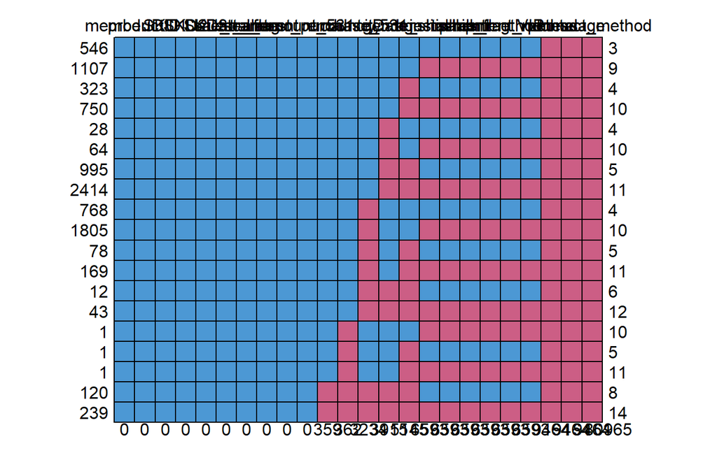

```
##      memberID productID SKU1 SKU2 SKU3 Date_trans sales_amount flag
## 546         1         1    1    1    1          1            1    1
## 1107        1         1    1    1    1          1            1    1
## 323         1         1    1    1    1          1            1    1
## 750         1         1    1    1    1          1            1    1
## 28          1         1    1    1    1          1            1    1
## 64          1         1    1    1    1          1            1    1
## 995         1         1    1    1    1          1            1    1
## 2414        1         1    1    1    1          1            1    1
## 768         1         1    1    1    1          1            1    1
## 1805        1         1    1    1    1          1            1    1
## 78          1         1    1    1    1          1            1    1
## 169         1         1    1    1    1          1            1    1
## 12          1         1    1    1    1          1            1    1
## 43          1         1    1    1    1          1            1    1
```

[output cut: 69 more lines]

```r
md.pattern(df)
```

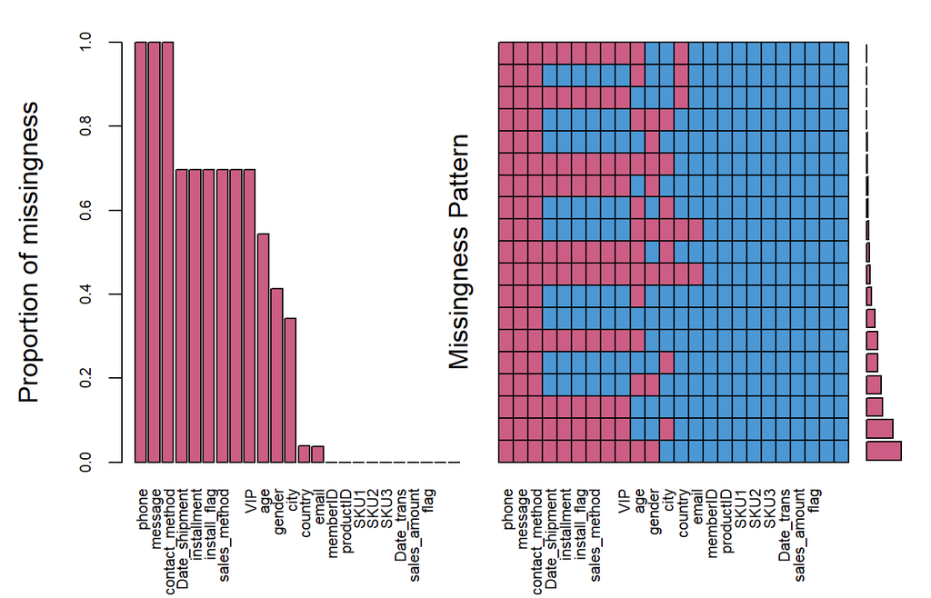

```
##
##  Variables sorted by number of missings:
##                  Variable      Count
##                     phone 1.00000000
##                   message 1.00000000
##            contact_method 1.00000000
##             Date_shipment 0.69663990
##               installment 0.69663990
##              install_flag 0.69663990
##              sales_method 0.69663990
##           shipment_method 0.69663990
##                       VIP 0.69663990
##                       age 0.54363905
##                    gender 0.41367287
##                      city 0.34171598
##                   country 0.03825021
##                     email 0.03793322
##                  memberID 0.00000000
##                 productID 0.00000000
##                      SKU1 0.00000000
##                      SKU2 0.00000000
##                      SKU3 0.00000000
##                Date_trans 0.00000000
##              sales_amount 0.00000000
##                      flag 0.00000000
##          total_amount_531 0.00000000
##  Date_latest_purchase_531 0.00000000
```

```r
aggr_df = aggr(df, col=mdc(1:2), numbers=TRUE, sortVars=TRUE, labels=names(df), cex.axis=.7, gap=1, ylab=c("Proportion of missingness","Missingness Pattern"))
```

From the plot on the left we could see, for variables as “phone”,“message”,“contact method”, their proportions of missingness are 1.0. They’re missings not at random with no method to imputate,so we have to delete these variables.

```r
df[,c("phone","message","contact_method")]<-NULL
```

For installment,install_flag,sales_method,shipment_method,and VIP, these variables all have same proportion of missing value. Let’s check if all the missing values happened within the same observations.

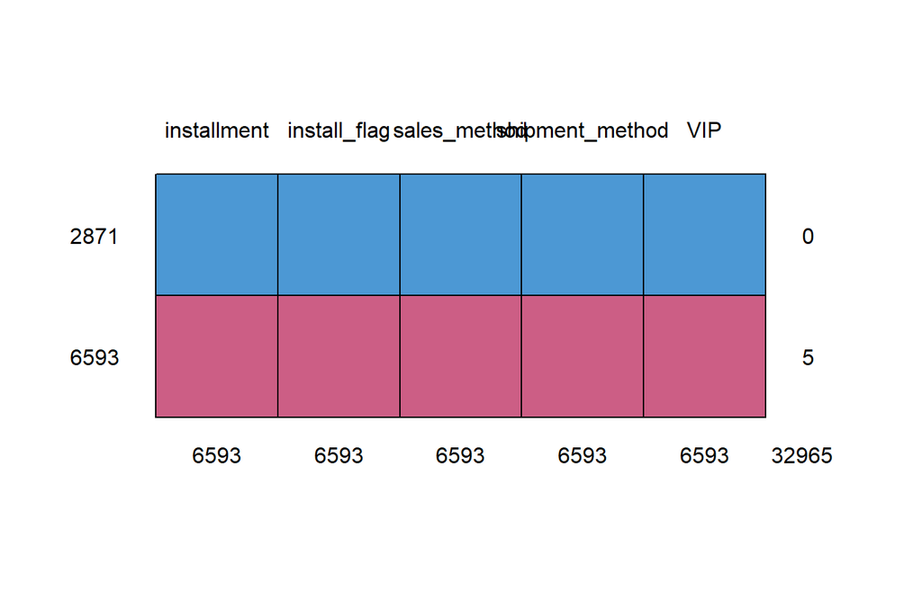

```
##      installment install_flag sales_method shipment_method  VIP
## 2871           1            1            1               1    1     0
## 6593           0            0            0               0    0     5
##             6593         6593         6593            6593 6593 32965
```

```r
md.pattern(df[,c("installment","install_flag","sales_method","shipment_method","VIP")])
```

```r
df$Date_shipment<-as.character(df$Date_shipment)
df[,c("installment","install_flag","sales_method","shipment_method","VIP")]<-lapply(df[,c("installment","install_flag","sales_method","shipment_method","VIP")],as.character)
df[c("Date_shipment","installment","install_flag","sales_method","shipment_method","VIP")][is.na(df[c("Date_shipment","installment","install_flag","sales_method","shipment_method","VIP")])]<-"unknown"
```

Demographic variables:one assumption for demographic variables is for the same memberID, it should have the same age,gender,city,country,total_amount and Date_latest_purchase. We can testify it and imputate missing values.

```r
df_test<-df%>%
  group_by(memberID)%>%
  summarize(n_age=n_distinct(age),n_gender=n_distinct(gender),n_city=n_distinct(city),n_country=n_distinct(country))
df_test[df_test$n_gender!=1|df_test$n_city!=1|df_test$n_country!=1,]
```

```
## # A tibble: 0 x 5
## # ... with 5 variables: memberID <dbl>, n_age <int>, n_gender <int>,
## #   n_city <int>, n_country <int>
```

After testify, besides several members’ age have increased by 1 year, every other variables only has one distinct value which follows our hypothesis.

Set age,gender NA as unknown.

```r
df[,c("age","gender")]<-lapply(df[,c("age","gender")],as.character)
df[c("age","gender")][is.na(df[c("age","gender")])]<-"unknown"
```

City and Country distribution

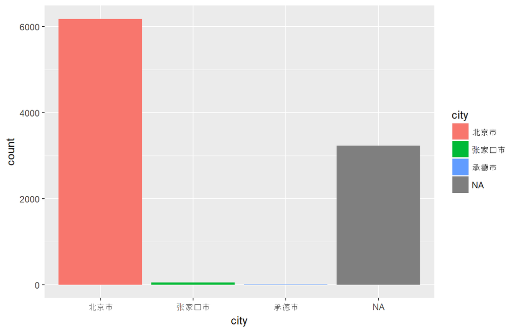

```r
ggplot(df,aes(city,fill=city))+geom_bar()
```

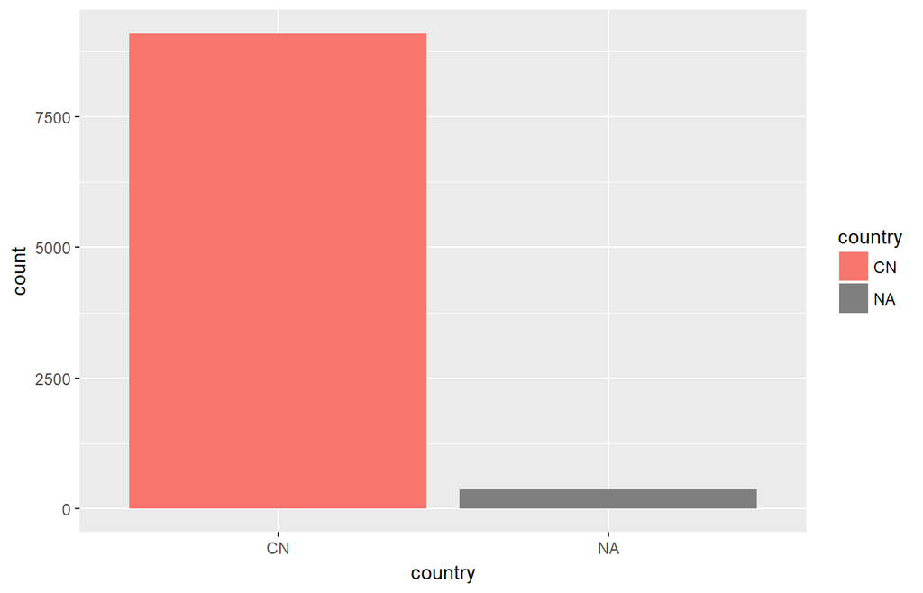

```r
ggplot(df,aes(country,fill=country))+geom_bar()
```

Based on mode,fill all NA city with “Beijing” and because all the countries is “CN”. There’s no need to include this variable in our prediction because of limited variation.

```r
#Fill NA city
df$city[is.na(df$city)]<-"北京市"

#Delete country variable
df$country<-NULL
```

Email distribution

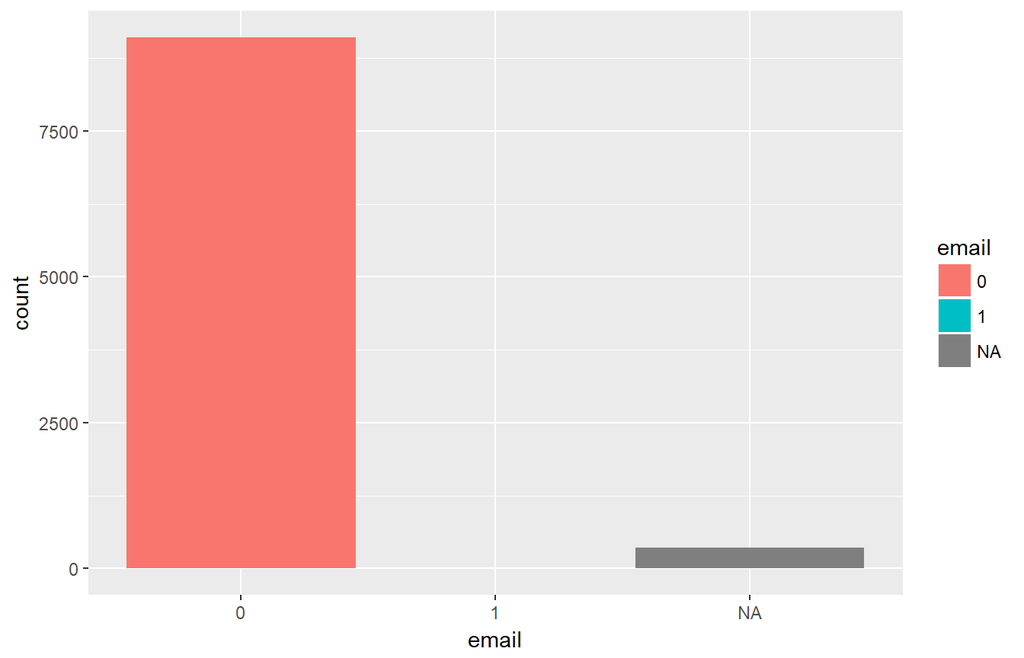

```r
ggplot(df,aes(email,fill=email))+geom_bar()
```

```r
#Fill NA with "0"
df$email[is.na(df$email)]<-0
```

## 3.5 Reformating variables

```r
df$Date_shipment<-as.Date(df$Date_shipment,format="%Y-%m-%d")

#Character to factor
df[,c("SKU3","installment","install_flag","sales_method","shipment_method","VIP","gender","city","email","flag")]<-lapply(df[,c("SKU3","installment","install_flag","sales_method","shipment_method","VIP","gender","city","email","flag")],as.factor)

df$age<-as.numeric(df$age)
```

## 3.6 Sanity Check

Let’s check the ourlier and replace it with mean value

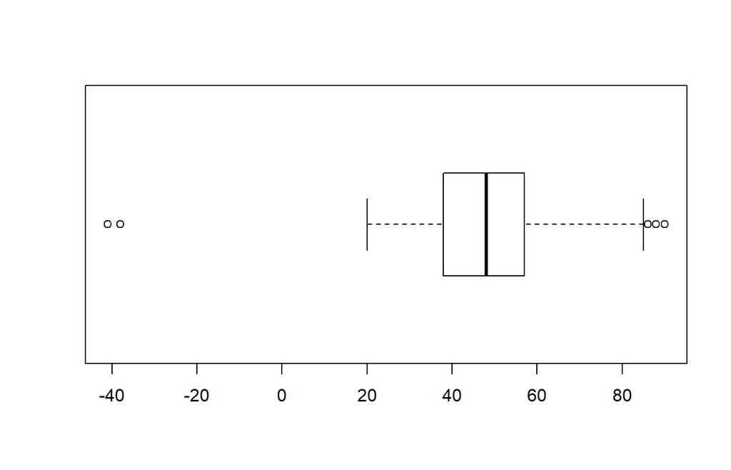

```r
boxplot(df$age,horizontal = TRUE,axes=TRUE)
```

```r
age_mean<-round(mean(df$age[df$age>0],na.rm = TRUE),0)
df$age[df$age<0]<-age_mean
```

We find there’re 54% of members with no age information.

```r
df%>%
  group_by(memberID)%>%
  summarize(age=mean(age))%>%
  summarize(na.prop=sum(is.na(age))/n())
```

```
## # A tibble: 1 x 1
##   na.prop
##     <dbl>
## 1   0.543
```

Let’s see what’s the relationship between age(without NA) and repeat purchase.From the density plot we could see the purchase rate is different between 30-50.

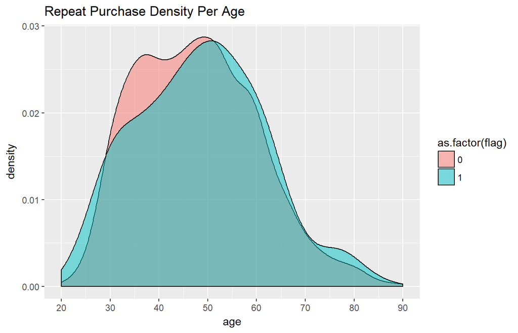

```r
df%>%
  group_by(memberID,flag)%>%
  summarize(age=mean(age))%>%
  ggplot(aes(age))+
  geom_density(alpha=0.5,aes(fill=as.factor(flag)))+
  labs(title="Repeat Purchase Density Per Age")+
  scale_x_continuous(breaks=seq(-50,100,by=10))
```

Let’s check the distribution of repeat purchase rate among members without age information.

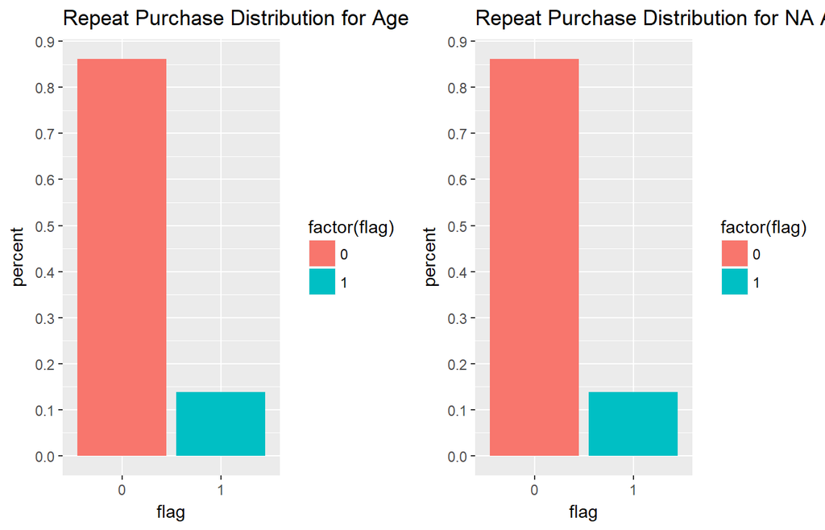

```r
p1<-df%>%
  select(age,flag,memberID)%>%
  filter(!is.na(age))%>%
  group_by(memberID,flag)%>%
  ggplot(aes(factor(flag),fill=factor(flag)))+
  geom_bar(aes(y=(..count..)/sum(..count..)))+
  scale_y_continuous(breaks=seq(0,1,by=0.1))+
  labs(x="flag",y="percent",title="Repeat Purchase Distribution for Age without NA")

p2<-df%>%
  select(age,flag,memberID)%>%
  filter(!is.na(age))%>%
  group_by(memberID,flag)%>%
  ggplot(aes(factor(flag),fill=factor(flag)))+
  geom_bar(aes(y=(..count..)/sum(..count..)))+
  scale_y_continuous(breaks=seq(0,1,by=0.1))+
  labs(x="flag",y="percent",title="Repeat Purchase Distribution for NA Age")

layout <- matrix(c(1,2),1,2,byrow=TRUE)
multiplot(p1, p2, layout=layout)
```

```r
#Create age group as (<30,30-50,50-70,>70,unknown)
df<-df%>%
  mutate(age_group=as.factor(case_when(age<30~"<30",
                             age>=30&age<=50~"30-50",
                             age>50&age<=70~"50-70",
                             age>70~">70",
                             is.na(age)~"unknown")))%>%
  select(-age)
df$age_group<-ordered(df$age_group,levels=c("unknown","30-50","50-70",">70"))
```

There’re some outliers in Date_shipment

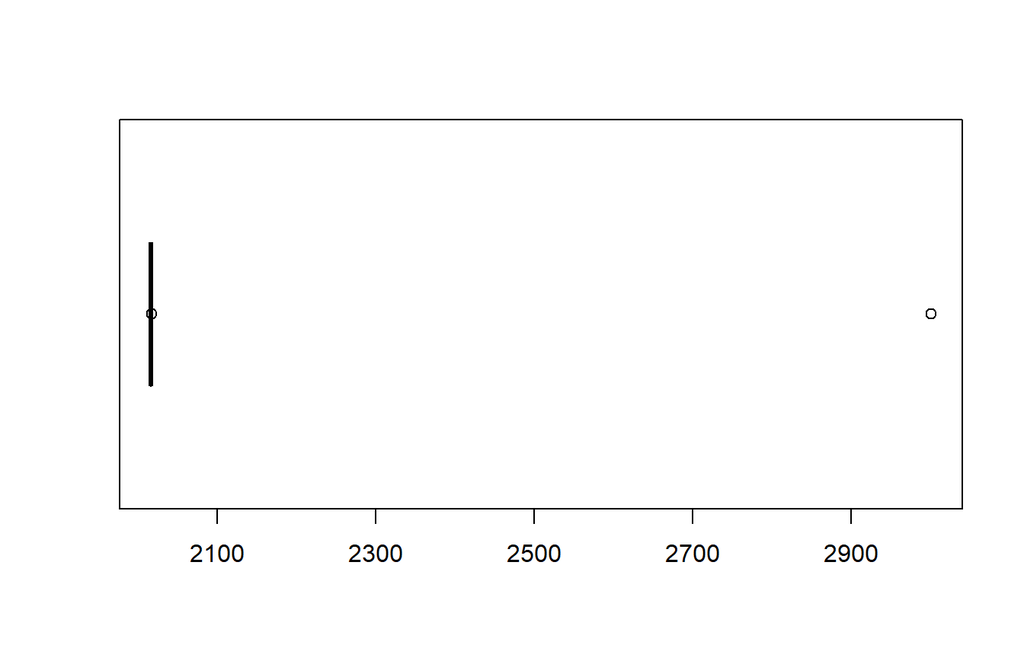

```r
boxplot(df$Date_shipment,horizontal = TRUE,axes=TRUE)
```

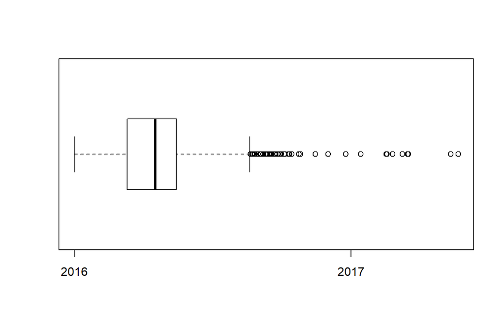

```r
#Remove outliers
df$Date_shipment[df$Date_shipment>as.Date("2017-06-01","%Y-%m-%d")]<-NA
boxplot(df$Date_shipment,horizontal = TRUE,axes=TRUE)
```

It looks like *install_flag* and *installment* are the same. Let’s check the variance of these two features.After check, we find there are identical. We have to delete one.

```r
nrow(df[df$installment==df$install_flag,])
```

```
## [1] 9464
```

```r
df$install_flag<-NULL
```

## 3.7 Final summary

```r
summary(df)
```

```
##     memberID           productID         SKU1          SKU2
##  Min.   :133456801   Min.   :223458701   G: 402   R38    :1061
##  1st Qu.:133792480   1st Qu.:223754544   R:9062   R46    :1017
##  Median :133913629   Median :223781386            R12    : 960
##  Mean   :133875248   Mean   :274120130            R03    : 826
##  3rd Qu.:134026305   3rd Qu.:223850908            R31    : 617
##  Max.   :134110096   Max.   :663522212            R32    : 615
##                                                   (Other):4368
##       SKU3      Date_shipment            gender
##  R4601  :1017   Min.   :2016-01-01   0      :3704
##  R0301  : 826   1st Qu.:2016-03-11   1      :1845
##  R3201  : 580   Median :2016-04-17   unknown:3915
##  R0101  : 566   Mean   :2016-04-13
##  R0601  : 529   3rd Qu.:2016-05-15
##  R1202  : 518   Max.   :2017-05-23
##  (Other):5428   NA's   :6595
##                                city      email     installment
##  北京市        :3234   0:9463   1      :1172
##  北京市        :6183   1:   1   2      :1357
##  张家口市:  45            3      : 192
##  承德市        :   2            4      : 150
##                                                   unknown:6593
##
##
##    Date_trans          sales_amount     sales_method  shipment_method
##  Min.   :2016-01-01   Min.   :   0.0   0      :2854   1      :  19
##  1st Qu.:2016-02-13   1st Qu.:  11.5   1      :  17   2      :1885
##  Median :2016-03-25   Median : 109.8   unknown:6593   3      : 728
##  Mean   :2016-03-20   Mean   : 199.9                  4      :   7
##  3rd Qu.:2016-04-29   3rd Qu.: 319.9                  5      :  46
##  Max.   :2016-05-31   Max.   :3190.0                  6      : 186
##                                                       unknown:6593
##       VIP       flag     total_amount_531  Date_latest_purchase_531
##  0      :2871   0:8188   Min.   :    0.2   Min.   :2016-01-01
##  unknown:6593   1:1276   1st Qu.:  639.8   1st Qu.:2016-02-25
##                          Median : 1246.5   Median :2016-04-03
##                          Mean   : 2194.6   Mean   :2016-03-26
##                          3rd Qu.: 2416.1   3rd Qu.:2016-05-01
##                          Max.   :42865.0   Max.   :2016-05-31
##
##    age_group
##  unknown:5145
##  30-50  :2274
##  50-70  :1657
##  >70    : 179
##  NA's   : 209
##
##
```

# 4 Feature Engineering

Becasue features are very important to predictive models and with oringinal dataset we only have features including product profile, demographic profile and shipment profile, it’s essential to create more target-related features and explore their significants to classify target variable. Our feature engineering process includes:  
1. Feature classification 2. Feature initial exploratory 2. Feature construction  
3. Feature initial selection(included in next part)

## 4.1 Feature classification

All the original features could be divided into product profile, demographic profile and shipment profile. We’ll assign them into three groups and create new features based on them. We can also classify features based on class: character,categorical feature, numeric features(integer and float),date.

```r
colnames(df)
```

```
##  [1] "memberID"                 "productID"
##  [3] "SKU1"                     "SKU2"
##  [5] "SKU3"                     "Date_shipment"
##  [7] "gender"                   "city"
##  [9] "email"                    "installment"
## [11] "Date_trans"               "sales_amount"
## [13] "sales_method"             "shipment_method"
## [15] "VIP"                      "flag"
## [17] "total_amount_531"         "Date_latest_purchase_531"
## [19] "age_group"
```

```r
# classification based on feature nature
product_cl<-c("productID","SKU1","SKU2","SKU3","Date_trans","sales_amount","sales_method")
user_cl<-c("memberID","age_group","gender","city","email","total_amount_531","Date_latest_purchase_531")
shipment_cl<-c("Date_shipment","installment","install_flag","shipment_method","VIP")

#classification based on feature class
cha_cl<-c("memberID","productID")
cat_cl<-c("SKU1","SKU2","SKU3","gender","city","email","installment","install_flag","sales_method","shipment_method","VIP","flag","age_group")
date_cl<-c("Date_shipment","Date_trans","Date_latest_purchase_531")
float_cl<-c("sales_amount","total_amount_531")
```

## 4.2 Feature initial exploratory

Next, we’ll plot the distribution of each variable and the relationship between independ variable and target to decide which variable need further construction.

### Split training and testing dataset

To avoid overfitting, our exploratory part should only include training dataset.

```r
#Add date features
df<-df%>%
mutate(week=week(Date_trans),weekday=weekdays(Date_trans),month=month(Date_trans))

#Split stratified traing and testing data
df_customer_list<-df%>%
  group_by(memberID,flag)%>%
  summarize(cou=n())

set.seed(1234)
train.index<-createDataPartition(df_customer$flag, p = .7, list = FALSE)
df_train_customer<-df_customer_list[train.index,][,-(2:3)]
df_test_customer<-df_customer_list[-train.index,][,-(2:3)]

#Split original dataset
df_train<-inner_join(df,df_train_customer,by="memberID")
df_test<-inner_join(df,df_test_customer,by="memberID")
```

### 4.2.1 Individual features

From these individual features’ count visualizations, we could see how features distribute and we have to notice that some levels of features have limited count. We may combine it with multi-feature analysis and consider to remove it or integrate it to higher level.

#### Individual Categorical features part 1

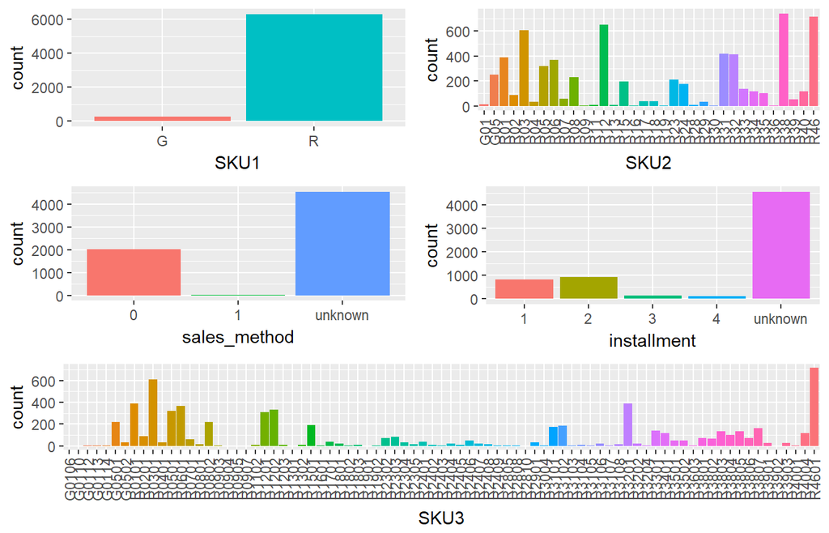

Fig. 1

```r
p1 <- df_train %>%
  ggplot(aes(SKU1, fill = SKU1)) +
  geom_bar() +
  theme(legend.position = "none")
p2 <- df_train %>%
  ggplot(aes(SKU2, fill = SKU2)) +
  geom_bar() +
  theme(legend.position = "none",axis.text.x=element_text(angle=90,hjust=1,vjust=0.5))
p3 <- df_train %>%
  ggplot(aes(SKU3, fill = SKU3)) +
  geom_bar() +
  theme(legend.position = "none",axis.text.x=element_text(angle=90,hjust=1,vjust=0.5))
p4 <- df_train %>%
  ggplot(aes(installment, fill = installment)) +
  geom_bar() +
  theme(legend.position = "none")

p6 <- df_train %>%
  ggplot(aes(sales_method, fill = sales_method)) +
  geom_bar() +
  theme(legend.position = "none")
layout <- matrix(c(1,2,3,4,5,5),3,2,byrow=TRUE)
multiplot(p1, p2, p6, p4, p3, layout=layout)
```

#### Individual Categorical features part 2

[figure not shown]

Fig. 2

```r
df_train[df_train$memberID=="133867735","age_group"]<-"30-50"

df_train_group<-df_train%>%
  group_by(memberID,gender,city,email,flag,age_group)%>%
  summarize(count=n(),total_amount_531=mean(total_amount_531),total_amount_2016=sum(sales_amount))
df_train_group<-data.frame(df_train_group)

p1 <- df_train %>%
  ggplot(aes(shipment_method, fill = shipment_method)) +
  geom_bar() +
  theme(legend.position = "none")
p2 <- df_train %>%
  ggplot(aes(VIP, fill = VIP)) +
  geom_bar() +
  theme(legend.position = "none")
p3 <- df_train_group %>%
  ggplot(aes(gender, fill = gender)) +
  geom_bar() +
  theme(legend.position = "none")
p4 <- df_train_group %>%
  ggplot(aes(city, fill = city)) +
  geom_bar() +
  theme(legend.position = "none",axis.text.x=element_text(angle=90,hjust=1,vjust=0.5))
p5 <- df_train_group %>%
  ggplot(aes(email, fill = email)) +
  geom_bar() +
  theme(legend.position = "none")
p6 <- df_train_group %>%
  ggplot(aes(age_group, fill = age_group)) +
  geom_bar() +
  theme(legend.position = "none")
layout <- matrix(c(1,2,3,4,5,6),3,2,byrow=TRUE)
multiplot(p1, p2, p3, p4, p5, p6, layout=layout)
```

#### Individual Numeric features

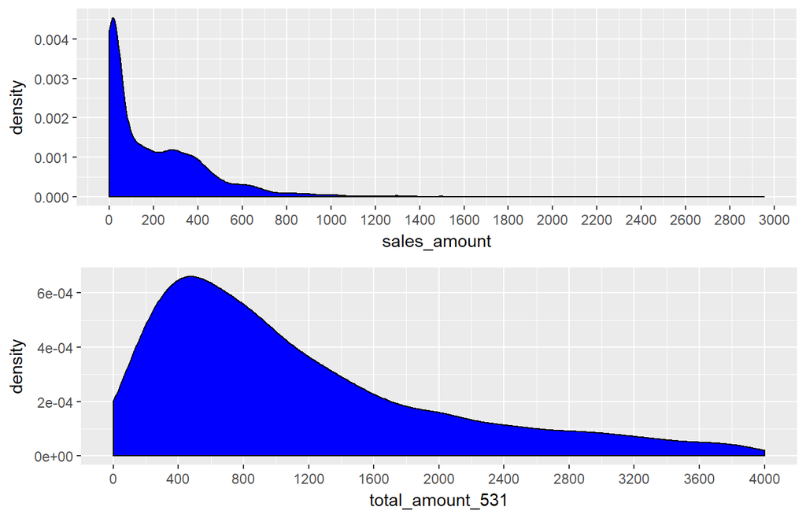

Fig. 3

```r
p1 <- df_train %>%
  ggplot(aes(sales_amount, fill = sales_amount)) +
  geom_density(fill = "blue") +
  theme(legend.position = "none")+
  scale_x_continuous(breaks=seq(0,3000,200))
p2 <- df_train_group %>%
  ggplot(aes(total_amount_531, fill = total_amount_531)) +
  geom_density(fill = "blue") +
  theme(legend.position = "none")+
  scale_x_continuous(limits=c(1,4000),breaks=seq(0,4000,400))
p3 <- df_train_group %>%
  ggplot(aes(total_amount_2016, fill = total_amount_2016)) +
  geom_density(fill = "blue") +
  theme(legend.position = "none")+
  scale_x_continuous(limits=c(1,4000),breaks=seq(0,5000,500))

layout <- matrix(c(1,2),2,1,byrow=TRUE)
multiplot(p1, p2, layout=layout)
```

#### Individual Date features

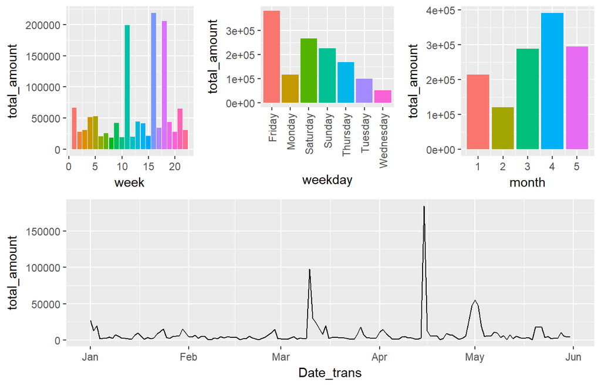

Fig. 4

```r
##sales pattern
p1<-df_train%>%
  group_by(week)%>%
  summarize(total_amount=sum(sales_amount))%>%
  ggplot()+geom_bar(aes(week,total_amount,fill=as.factor(week)),stat="identity")+theme(legend.position = "none")
p2<-df_train%>%
  group_by(weekday)%>%
  summarize(total_amount=sum(sales_amount))%>%
  ggplot()+geom_bar(aes(weekday,total_amount,fill=as.factor(weekday)),stat="identity")+theme(legend.position = "none",axis.text.x=element_text(angle=90,hjust=1,vjust=0.5))
p3<-df_train%>%
  group_by(month)%>%
  summarize(total_amount=sum(sales_amount))%>%
  ggplot()+geom_bar(aes(month,total_amount,fill=as.factor(month)),stat="identity")+theme(legend.position = "none")
p4<-df_train%>%
  group_by(Date_trans)%>%
  summarize(total_amount=sum(sales_amount))%>%
  ggplot()+geom_line(aes(Date_trans,total_amount))+theme(legend.position = "none")
layout <- matrix(c(1,2,3,4,4,4),2,3,byrow=TRUE)
multiplot(p1, p2,p3,p4, layout=layout)
```

### 4.2.2 Repeat Purchase Rate for individual features

Next we have to explore the relationship among repeat purchase and individual features to decide which feature is important when classifing target. We also add error margin with 95% confidence level based on statistical significance calculation on “repeat purchase”.

Conclusion: The features which we find have significant different repeated purchase rate are:  
1. *SKU1*  
2. *sales_method*  
3. *shipment_method*(1 and the other)  
4. *VIP*  
5. *total_amount_531*  
6. *total_amount_2016*

#### Interaction-Categorical features with target part 1

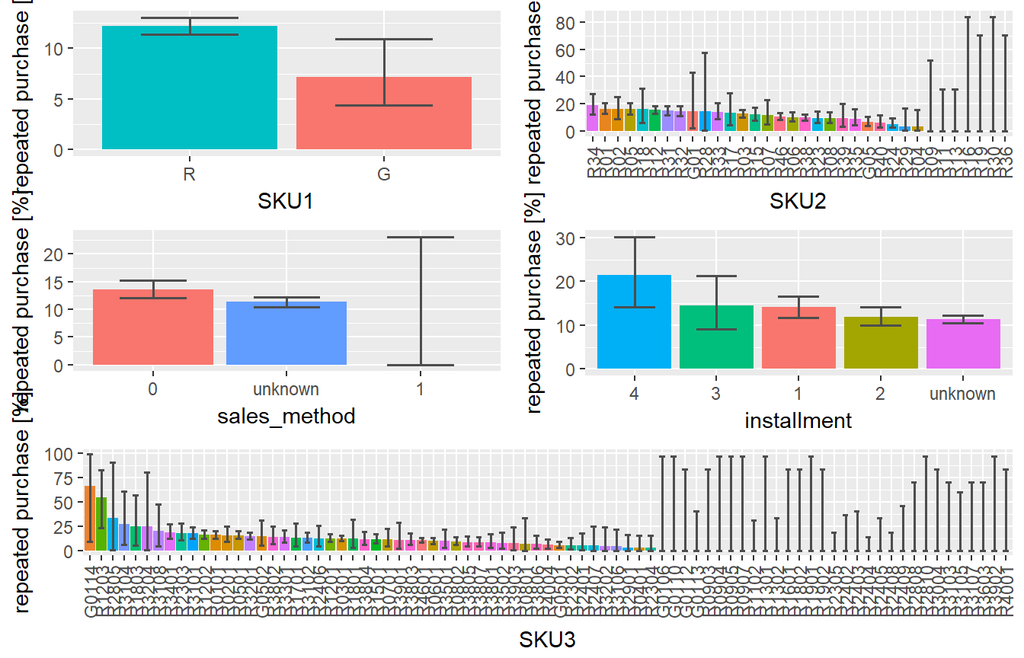

Fig. 1

```r
p1 <- df_train %>%
  group_by(SKU1, flag) %>%
  count() %>%
  spread(flag, n) %>%
  mutate(frac_claim = `1`/(`1`+`0`)*100,
         lwr = get_CI(`1`,(`1`+`0`))[[1]]*100,
         upr = get_CI(`1`,(`1`+`0`))[[2]]*100
         ) %>%
  ggplot(aes(reorder(SKU1, -frac_claim, FUN = max), frac_claim, fill = SKU1)) +
  geom_col() +
  geom_errorbar(aes(ymin = lwr, ymax = upr), width = 0.5, size = 0.7, color = "gray30") +
  theme(legend.position = "none") +
  labs(x = "SKU1", y = "repeated purchase [%]")

p2 <- df_train %>%
  group_by(SKU2, flag) %>%
  count() %>%
  spread(flag, n,fill=0) %>%
  mutate(frac_claim = `1`/(`1`+`0`)*100,
         lwr = get_CI(`1`,(`1`+`0`))[[1]]*100,
         upr = get_CI(`1`,(`1`+`0`))[[2]]*100
         ) %>%
  ggplot(aes(reorder(SKU2, -frac_claim, FUN = max), frac_claim, fill = SKU2)) +
  geom_col() +
  geom_errorbar(aes(ymin = lwr, ymax = upr), width = 0.5, size = 0.7, color = "gray30") +
  theme(legend.position = "none",axis.text.x=element_text(angle=90,hjust=1,vjust=0.5)) +
  labs(x = "SKU2", y = "repeated purchase [%]")

p3 <- df_train %>%
  group_by(SKU3, flag) %>%
  count() %>%
  spread(flag, n,fill=0) %>%
  mutate(frac_claim = `1`/(`1`+`0`)*100,
         lwr = get_CI(`1`,(`1`+`0`))[[1]]*100,
         upr = get_CI(`1`,(`1`+`0`))[[2]]*100
         ) %>%
  ggplot(aes(reorder(SKU3, -frac_claim, FUN = max), frac_claim, fill = SKU3)) +
  geom_col() +
  geom_errorbar(aes(ymin = lwr, ymax = upr), width = 0.5, size = 0.7, color = "gray30") +
  theme(legend.position = "none",axis.text.x=element_text(angle=90,hjust=1,vjust=0.5)) +
  labs(x = "SKU3", y = "repeated purchase [%]")

p4 <- df_train %>%
  group_by(installment, flag) %>%
  count() %>%
  spread(flag, n,fill=0) %>%
  mutate(frac_claim = `1`/(`1`+`0`)*100,
         lwr = get_CI(`1`,(`1`+`0`))[[1]]*100,
         upr = get_CI(`1`,(`1`+`0`))[[2]]*100
         ) %>%
  ggplot(aes(reorder(installment, -frac_claim, FUN = max), frac_claim, fill = installment)) +
  geom_col() +
  geom_errorbar(aes(ymin = lwr, ymax = upr), width = 0.5, size = 0.7, color = "gray30") +
  theme(legend.position = "none") +
  labs(x = "installment", y = "repeated purchase [%]")


p6 <- df_train %>%
  group_by(sales_method, flag) %>%
  count() %>%
  spread(flag, n,fill=0) %>%
  mutate(frac_claim = `1`/(`1`+`0`)*100,
         lwr = get_CI(`1`,(`1`+`0`))[[1]]*100,
         upr = get_CI(`1`,(`1`+`0`))[[2]]*100
         ) %>%
  ggplot(aes(reorder(sales_method, -frac_claim, FUN = max), frac_claim, fill = sales_method)) +
  geom_col() +
  geom_errorbar(aes(ymin = lwr, ymax = upr), width = 0.5, size = 0.7, color = "gray30") +
  theme(legend.position = "none") +
  labs(x = "sales_method", y = "repeated purchase [%]")

layout <- matrix(c(1,2,3,4,5,5),3,2,byrow=TRUE)
multiplot(p1, p2, p6, p4, p3, layout=layout)
```

#### Interaction-Categorical features with target part 2

[figure not shown]

Fig. 2

```r
p1 <- df_train %>%
  group_by(shipment_method, flag) %>%
  count() %>%
  spread(flag, n,fill=0) %>%
  mutate(frac_claim = `1`/(`1`+`0`)*100,
         lwr = get_CI(`1`,(`1`+`0`))[[1]]*100,
         upr = get_CI(`1`,(`1`+`0`))[[2]]*100
         ) %>%
  ggplot(aes(reorder(shipment_method, -frac_claim, FUN = max), frac_claim, fill = shipment_method)) +
  geom_col() +
  geom_errorbar(aes(ymin = lwr, ymax = upr), width = 0.5, size = 0.7, color = "gray30") +
  theme(legend.position = "none") +
  labs(x = "shipment_method", y = "repeated purchase [%]")

p2 <- df_train %>%
  group_by(VIP, flag) %>%
  count() %>%
  spread(flag, n,fill=0) %>%
  mutate(frac_claim = `1`/(`1`+`0`)*100,
         lwr = get_CI(`1`,(`1`+`0`))[[1]]*100,
         upr = get_CI(`1`,(`1`+`0`))[[2]]*100
         ) %>%
  ggplot(aes(reorder(VIP, -frac_claim, FUN = max), frac_claim, fill = VIP)) +
  geom_col() +
  geom_errorbar(aes(ymin = lwr, ymax = upr), width = 0.5, size = 0.7, color = "gray30") +
  theme(legend.position = "none") +
  labs(x = "VIP", y = "repeated purchase [%]")

p3 <- df_train_group %>%
  group_by(gender, flag) %>%
  count() %>%
  spread(flag, n,fill=0) %>%
  mutate(frac_claim = `1`/(`1`+`0`)*100,
         lwr = get_CI(`1`,(`1`+`0`))[[1]]*100,
         upr = get_CI(`1`,(`1`+`0`))[[2]]*100
         ) %>%
  ggplot(aes(reorder(gender, -frac_claim, FUN = max), frac_claim, fill = gender)) +
  geom_col() +
  geom_errorbar(aes(ymin = lwr, ymax = upr), width = 0.5, size = 0.7, color = "gray30") +
  theme(legend.position = "none") +
  labs(x = "gender", y = "repeated purchase [%]")

p4 <- df_train_group %>%
  group_by(city, flag) %>%
  count() %>%
  spread(flag, n,fill=0) %>%
  mutate(frac_claim = `1`/(`1`+`0`)*100,
         lwr = get_CI(`1`,(`1`+`0`))[[1]]*100,
         upr = get_CI(`1`,(`1`+`0`))[[2]]*100
         ) %>%
  ggplot(aes(reorder(city, -frac_claim, FUN = max), frac_claim, fill = city)) +
  geom_col() +
  geom_errorbar(aes(ymin = lwr, ymax = upr), width = 0.5, size = 0.7, color = "gray30") +
  theme(legend.position = "none",axis.text.x=element_text(angle=90,hjust=1,vjust=0.5)) +
  labs(x = "city", y = "repeated purchase [%]")

p5 <- df_train_group %>%
  group_by(email, flag) %>%
  count() %>%
  spread(flag, n,fill=0) %>%
  mutate(frac_claim = `1`/(`1`+`0`)*100,
         lwr = get_CI(`1`,(`1`+`0`))[[1]]*100,
         upr = get_CI(`1`,(`1`+`0`))[[2]]*100
         ) %>%
  ggplot(aes(reorder(email, -frac_claim, FUN = max), frac_claim, fill = email)) +
  geom_col() +
  geom_errorbar(aes(ymin = lwr, ymax = upr), width = 0.5, size = 0.7, color = "gray30") +
  theme(legend.position = "none") +
  labs(x = "email", y = "repeated purchase [%]")

p6 <- df_train_group %>%
  group_by(age_group, flag) %>%
  count() %>%
  spread(flag, n,fill=0) %>%
  mutate(frac_claim = `1`/(`1`+`0`)*100,
         lwr = get_CI(`1`,(`1`+`0`))[[1]]*100,
         upr = get_CI(`1`,(`1`+`0`))[[2]]*100
         ) %>%
  ggplot(aes(reorder(age_group, -frac_claim, FUN = max), frac_claim, fill = age_group)) +
  geom_col() +
  geom_errorbar(aes(ymin = lwr, ymax = upr), width = 0.5, size = 0.7, color = "gray30") +
  theme(legend.position = "none") +
  labs(x = "age_group", y = "repeated purchase [%]")

layout <- matrix(c(1,2,3,4,5,6),3,2,byrow=TRUE)
multiplot(p1, p2, p3, p4, p5, p6, layout=layout)
```

#### Interaction-Date features with target part 2

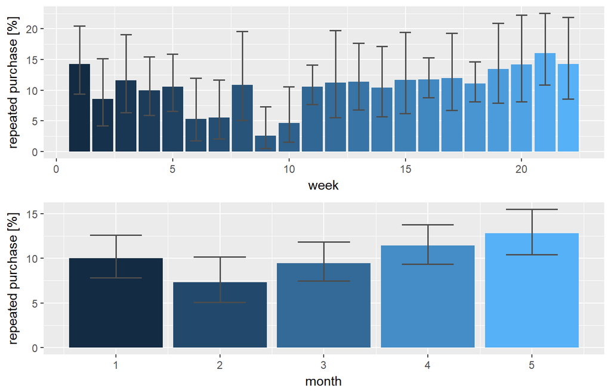

Fig. 3

```r
p1<-df_train%>%
  group_by(week,flag)%>%
  summarize(n=n_distinct(memberID))%>%
  spread(flag,n,fill=0)%>%
  mutate(frac_claim = `1`/(`1`+`0`)*100,
         lwr = get_CI(`1`,(`1`+`0`))[[1]]*100,
         upr = get_CI(`1`,(`1`+`0`))[[2]]*100
         ) %>%
  ggplot(aes(week, frac_claim, fill = week)) +
  geom_col() +
  geom_errorbar(aes(ymin = lwr, ymax = upr), width = 0.5, size = 0.7, color = "gray30") +
  theme(legend.position = "none") +
  labs(x = "week", y = "repeated purchase [%]")

p2<-df_train%>%
  group_by(month,flag)%>%
  summarize(n=n_distinct(memberID))%>%
  spread(flag,n,fill=0)%>%
  mutate(frac_claim = `1`/(`1`+`0`)*100,
         lwr = get_CI(`1`,(`1`+`0`))[[1]]*100,
         upr = get_CI(`1`,(`1`+`0`))[[2]]*100
         ) %>%
  ggplot(aes(month, frac_claim, fill = month)) +
  geom_col() +
  geom_errorbar(aes(ymin = lwr, ymax = upr), width = 0.5, size = 0.7, color = "gray30") +
  theme(legend.position = "none") +
  labs(x = "month", y = "repeated purchase [%]")

layout <- matrix(c(1,2),2,1,byrow=TRUE)
multiplot(p1, p2, layout=layout)
```

#### Interaction-Numeric features with target

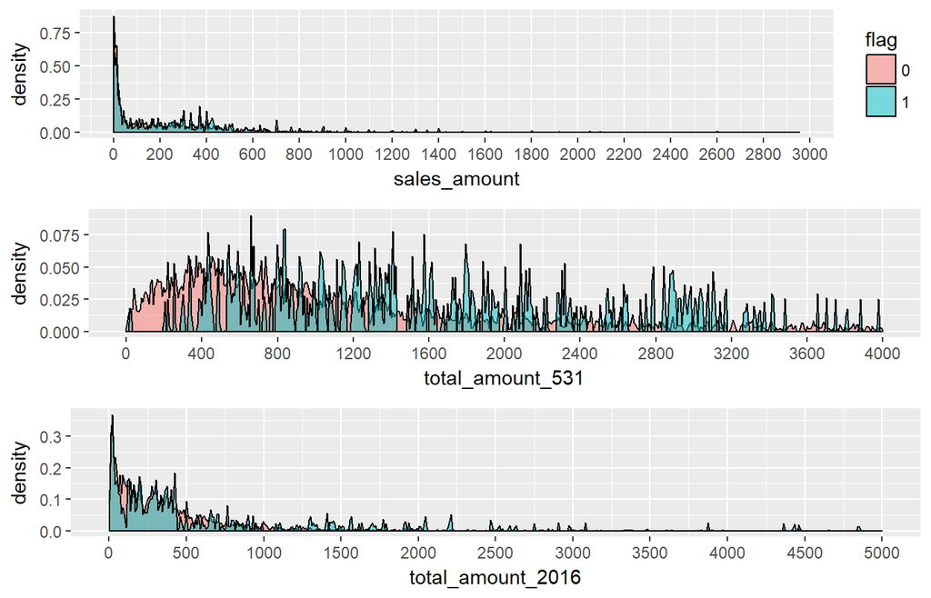

Fig. 4

```r
p1 <- df_train %>%
  ggplot(aes(sales_amount, fill =flag)) +
  geom_density(alpha = 0.5, bw = 0.05) +
  scale_x_continuous(breaks=seq(0,3000,200))

p2 <- df_train_group %>%
  ggplot(aes(total_amount_531, fill =flag)) +
  geom_density(alpha = 0.5, bw = 0.05) +
  theme(legend.position = "none")+
  scale_x_continuous(limits=c(1,4000),breaks=seq(0,4000,400))

p3 <- df_train_group %>%
  ggplot(aes(total_amount_2016, fill =flag)) +
  geom_density(alpha = 0.5, bw = 0.05) +
  theme(legend.position = "none")+
  scale_x_continuous(limits=c(1,5000),breaks=seq(0,5000,500))

layout <- matrix(c(1,2,3),3,1,byrow=TRUE)
multiplot(p1, p2,p3, layout=layout)
```

### 4.2.3 Multi-dimension relationship

#### Correlation

Let’s check if there is any feature having strong correlation. If there is, we may consider remove high correlated independent features and find features with high correlation with *flag*.

Conclusion:  
1. *installment*,*sales_method*,*shipment_method*,*VIP* have strong correlation because they belong to same observation when the data is missing.  
2. *sales_amount* and *flag* have weak positive correlation.  
3. *sales_amount_531* and *flag* have positive correlation.

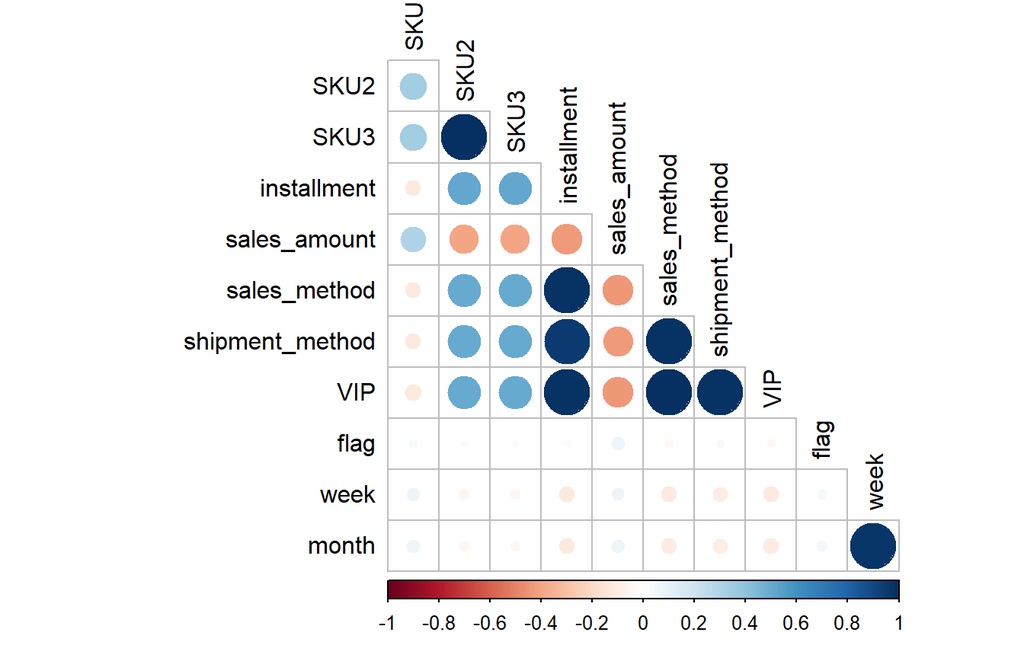

```r
df_train[,!(colnames(df_train) %in% user_cl)]%>%
  select(-productID,-Date_shipment,-Date_trans,-weekday)%>%
  mutate_at(vars(SKU1,SKU2,SKU3,installment,sales_method,shipment_method,VIP,flag,month,week),funs(as.integer))%>%
  cor(use="complete.obs", method = "spearman") %>%
  corrplot(type="lower", tl.col = "black",  diag=FALSE)
```

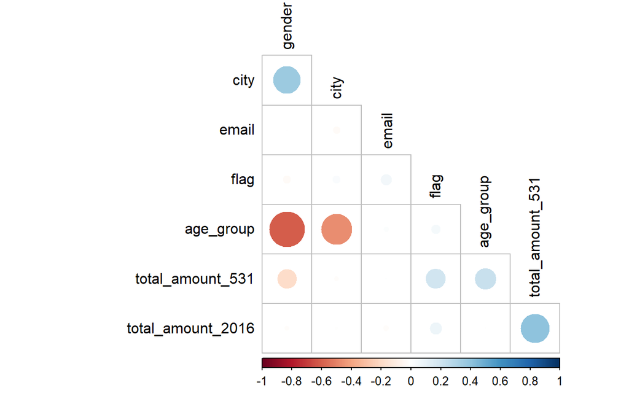

```r
df_train_group%>%
  select(-count,-memberID)%>%
  mutate_at(vars(gender,age_group,city,email,flag),funs(as.integer))%>%
  cor(use="complete.obs", method = "spearman") %>%
  corrplot(type="lower", tl.col = "black",  diag=FALSE)
```

### 4.2.4 conclusion

We find these features as important variables to identify “flag”. We can use these features to construct more features.  
*SKU1* *sales_method* *shipment_method*(1 or other) *sales_amount* *sales_amount_531* *sales_amount_2016*

## 4.3 Feature construction

### 4.3.1 Customer-based product feature construction

Because we find total_sales_amount is very important to predict repeated purchase. We combine user and product features and add aggregation of these feature to capture the characteristics. We also add recent activity as a signal of buy/not buy. The features we create are classified as:  
1. count/ratio by month: ex:total purchase amount/count/unique product for each customer  
2. aggregation: ex:sd,mean,sum of features in 1  
3. Recent activity: ex:last month purchase amount/total amount ratio, last two month purchase ratio..

```r
# Create count/ratio features

df1<-df%>%
  group_by(memberID,month)%>%
  summarize(purchase_item_count_month=sum(n()),
            purchase_amount_month=sum(sales_amount),
            purchase_u_product_month=sum(n_distinct(productID)),
            purchase_u_SKU1_month=sum(n_distinct(SKU1)),
            purchase_days=sum(n_distinct(Date_trans)))
df1<-melt(df1,id.vars=1:2)
df1<-dcast(df1,memberID~month+variable)
df1[is.na(df1)]<-0

#Aggregation variable
df1<-df1%>%
  mutate(sum_purchase_item_count=apply(df1[,grepl("purchase_item_count",names(df1)),],1,sum),
         sum_purchase_amount=apply(df1[,grepl("purchase_amount",names(df1)),],1,sum),
         sum_purchase_u_product=apply(df1[,grepl("purchase_u_product",names(df1)),],1,sum),
         sum_purchase_u_SKU1=apply(df1[,grepl("purchase_u_SKU1",names(df1)),],1,sum),
         sum_purchase_days=apply(df1[,grepl("purchase_days",names(df1)),],1,sum),
         mean_purchase_item_count=apply(df1[,grepl("purchase_item_count",names(df1)),],1,mean),
         mean_purchase_amount=apply(df1[,grepl("purchase_amount",names(df1)),],1,mean),
         mean_purchase_u_product=apply(df1[,grepl("purchase_u_product",names(df1)),],1,mean),
         mean_purchase_u_SKU1=apply(df1[,grepl("purchase_u_SKU1",names(df1)),],1,mean),
         mean_purchase_days=apply(df1[,grepl("purchase_days",names(df1)),],1,mean),
         sd_purchase_item_count=apply(df1[,grepl("purchase_item_count",names(df1)),],1,sd),
         sd_purchase_amount=apply(df1[,grepl("purchase_amount",names(df1)),],1,sd),
         sd_purchase_u_product=apply(df1[,grepl("purchase_u_product",names(df1)),],1,sd),
         sd_purchase_u_SKU1=apply(df1[,grepl("purchase_u_SKU1",names(df1)),],1,sd),
         sd_purchase_days=apply(df1[,grepl("purchase_days",names(df1)),],1,sd)
         )
#repeat purchase
df1$repeat_purchase<-as.factor(ifelse(df1$sum_purchase_days>1,1,0))

#Recent activity
df1<-df1%>%
  mutate(R1_month_purchase_item_ratio=round(`5_purchase_item_count_month`/sum_purchase_item_count,2),
         R1_month_purchase_amount_ratio=round(`5_purchase_amount_month`/sum_purchase_amount,2),
         R1_purchase_u_product_ratio=round(`5_purchase_u_product_month`/sum_purchase_u_product,2),
         R1_purchase_u_SKU1_ratio=round(`5_purchase_u_SKU1_month`/sum_purchase_u_SKU1,2),
         R1_purchase_days_ratio=round(`5_purchase_days`/sum_purchase_days,2),
         R2_month_purchase_item_ratio=round((`5_purchase_item_count_month`+`4_purchase_item_count_month`)/sum_purchase_item_count,2),
         R2_month_purchase_amount_ratio=round((`5_purchase_amount_month`+`4_purchase_amount_month`)/sum_purchase_amount,2),
         R2_purchase_u_product_ratio=round((`5_purchase_u_product_month`+`4_purchase_u_product_month`)/sum_purchase_u_product,2),
         R2_purchase_u_SKU1_ratio=round((`5_purchase_u_SKU1_month`+`4_purchase_u_SKU1_month`)/sum_purchase_u_SKU1,2),
         R2_purchase_days_ratio=round((`5_purchase_days`+`4_purchase_days`)/sum_purchase_days,2))
```

Merge new features with original dataset and only include important features.

```r
#Using mode function to convert transaction-based feature to customer-based feature
Mode <- function(x) {
  ux <- unique(x)
  ux[which.max(tabulate(match(x, ux)))]
}
levels(df$shipment_method)<-c("1","0","0","0","0","0","0")

df2<-df%>%
  group_by(memberID,flag)%>%
  summarize(sales_method=Mode(sales_method),shipment_method=Mode(shipment_method), Date_latest_purchase_531=max(Date_latest_purchase_531),total_amount_531=mean(total_amount_531))%>%
  ungroup()%>%
  mutate(last_purchase_days=as.numeric(difftime(as.Date("2016-06-01","%Y-%m-%d"),Date_latest_purchase_531,units="days")))%>%
  mutate(last_purchase_weeks=round(last_purchase_days/7,0))%>%
  select(-Date_latest_purchase_531)


#Merge data together
df_all<-merge(df1,df2,by="memberID")

colnames(df_all)<-sub("^1_","Jan_",colnames(df_all))
colnames(df_all)<-sub("^2_","Feb_",colnames(df_all))
colnames(df_all)<-sub("^3_","Mar_",colnames(df_all))
colnames(df_all)<-sub("^4_","Apr_",colnames(df_all))
colnames(df_all)<-sub("^5_","May_",colnames(df_all))

#df_all$repeat_purchase<-as.factor(df_all$repeat_purchase)
```

Arrange data and delete unuseful data

```r
#Split original dataset
df_train<-inner_join(df_all,df_train_customer,by="memberID")
df_test<-inner_join(df_all,df_test_customer,by="memberID")

#delete all the other dataset
rm(list=setdiff(ls(), c("df_train","df_all","df_test","multiplot")))
```

# 5 Classification Prediction

## 5.1 Benchmark Test

First create different task:task with/without normalization.

```r
#Create task
classif.task=makeClassifTask(id="classif.task",data=df_all[,-1],target="flag",positive = 1)

#Create train and test task
#training task without normalization/dummy features
train_task<-makeClassifTask(id="classif.task",data=df_train[,-1],target="flag",positive = 1)
train_task$task.desc$id<-"train_task"


#training task with dummy features
train_task_dummy<-createDummyFeatures(train_task)
train_task_dummy$task.desc$id<-"train_task_dummy"


#training task with normalization and dummy features
train_task_normal<-normalizeFeatures(train_task)
train_task_normal$task.desc$id<-"train_task_normal"
train_task_normal<-createDummyFeatures(train_task_normal)


#testing task without normalization/dummy features
test_task<-makeClassifTask(id="classif.task",data=df_test[,-1],target="flag",positive = 1)
test_task$task.desc$id<-"test_task"
test_task<-createDummyFeatures(test_task)
#testing task with dummy features
test_task_dummy<-createDummyFeatures(test_task)
test_task_dummy$task.desc$id<-"test_task_dummy"


#testing task with normalization and dummy features
test_task_normal<-normalizeFeatures(test_task)
test_task_normal$task.desc$id<-"test_task_normal"
test_task_normal<-createDummyFeatures(test_task_normal)

#Because this dataset is imbalanced. So we use undersampling methods to eliminate the imbalance.
#train.task.under=undersample(train_task,rate=1/8)
#train.task.under.normal=undersample(train_task_normal,rate=1/8)
#train.task.under$task.desc$id="train.task.under"
#train.task.under.normal$task.desc$id="train.task.under.normal"
```

Try several basic models without feature selection and tunning.

```r
## Create a list of learners
lrns_list = listLearners(train_task_dummy, properties = "prob")
tasks=list(train_task_dummy,train_task_normal)

lrns = list(
  makeLearner("classif.glmnet", id = "glmnet",predict.type = "prob"),
  makeLearner("classif.logreg", id = "logreg",predict.type = "prob"),
  makeLearner("classif.rpart", id = "rpart",predict.type = "prob"),
  makeLearner("classif.randomForest", id = "randomForest",predict.type = "prob"),
  makeLearner("classif.xgboost", id = "xgboost",predict.type = "prob"),
  makeLearner("classif.gbm", id = "gbm",predict.type = "prob")
)
set.seed(1234)
rdesc = makeResampleDesc("CV", iters = 5)
meas = list(mmce, auc, acc,timetrain)
bmr = benchmark(lrns, tasks, rdesc, meas, show.info = FALSE)
```

```
## Exporting objects to slaves for mode socket: .mlr.slave.options
```

```
## Mapping in parallel: mode = socket; cpus = 4; elements = 12.
```

```r
bmr
```

```
##              task.id   learner.id mmce.test.mean auc.test.mean
## 1   train_task_dummy       glmnet     0.09706509     0.6361972
## 2   train_task_dummy       logreg     0.10093346     0.6028464
## 3   train_task_dummy        rpart     0.09674303     0.5000000
## 4   train_task_dummy randomForest     0.09835593     0.6361153
## 5   train_task_dummy      xgboost     0.10351774     0.6516687
## 6   train_task_dummy          gbm     0.09674303     0.6847779
## 7  train_task_normal       glmnet     0.09738819     0.6425550
## 8  train_task_normal       logreg     0.10093657     0.6012525
## 9  train_task_normal        rpart     0.09674355     0.5000000
## 10 train_task_normal randomForest     0.09996987     0.6505087
## 11 train_task_normal      xgboost     0.10770921     0.6338220
## 12 train_task_normal          gbm     0.09674355     0.6784193
##    acc.test.mean timetrain.test.mean
## 1      0.9029349               1.960
## 2      0.8990665               0.350
## 3      0.9032570               0.064
## 4      0.9016441               5.266
## 5      0.8964823               0.094
## 6      0.9032570               0.350
## 7      0.9026118               1.356
## 8      0.8990634               0.356
## 9      0.9032565               0.060
## 10     0.9000301               5.268
## 11     0.8922908               0.092
## 12     0.9032565               0.344
```

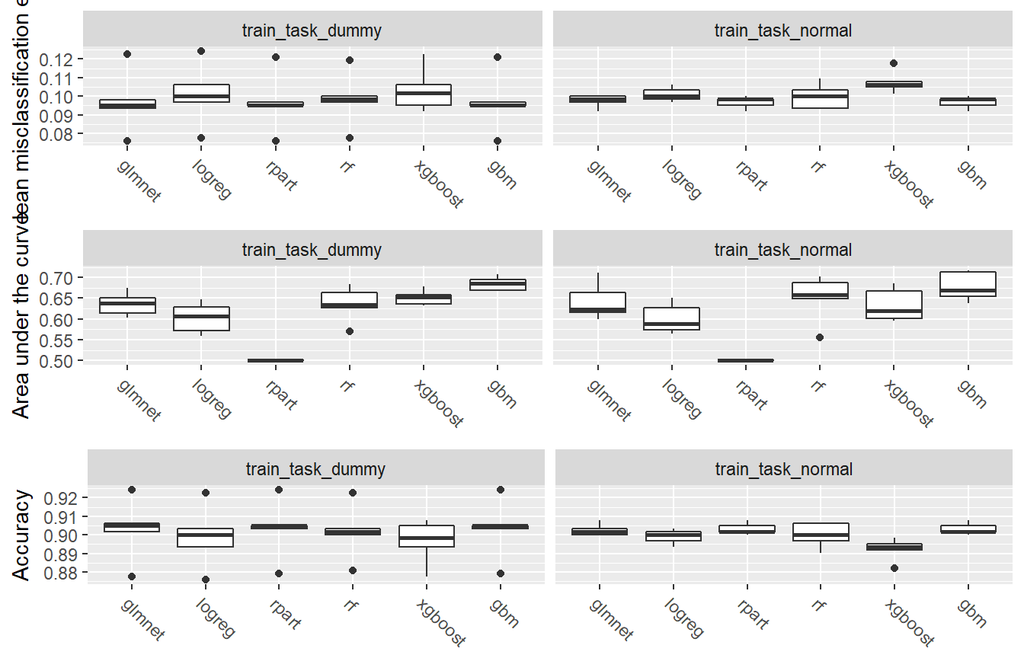

Fig. 1

```r
p1<-plotBMRBoxplots(bmr, measure = mmce)
p2<-plotBMRBoxplots(bmr, measure = auc)
p3<-plotBMRBoxplots(bmr, measure = acc)

layout <- matrix(c(1,2,3),3,1,byrow=TRUE)
multiplot(p1, p2, p3, layout=layout)
```

```r
mod_bmr=getBMRModels(bmr)
pred_bmr=predict(mod_bmr$train_task_normal$gbm[[1]],task=test_task_normal)
df = generateThreshVsPerfData(pred_bmr, measures = list(fpr, tpr, mmce))

#AUC performance on testing normal data with gbm
performance(pred_bmr, auc)
```

```
##       auc
## 0.6599101
```

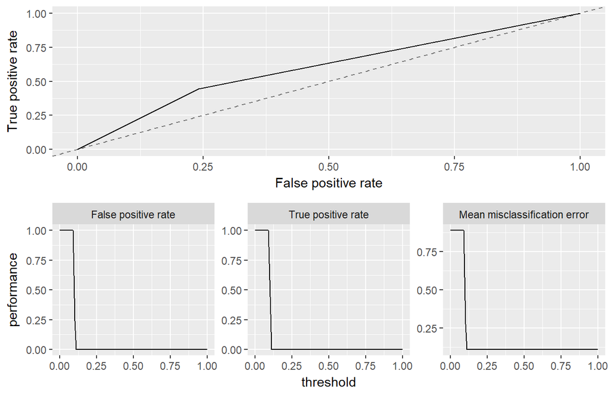

Fig. 1

```r
p1<-plotROCCurves(df)
p2<-plotThreshVsPerf(df)
layout <- matrix(c(1,2),2,1,byrow=TRUE)
multiplot(p1, p2, layout=layout)
```

## 5.2 Tree-related models

```r
# Create a list of learners

tasks=list(train_task,train_task_normal)

lrns = list(
  makeLearner("classif.rpart", id = "rpart",predict.type = "prob"),
  makeLearner("classif.randomForest", id = "randomForest",predict.type = "prob")
)
set.seed(1234)
rdesc = makeResampleDesc("CV", iters = 5)
meas = list(mmce, auc, acc,timetrain)
bmr = benchmark(lrns, tasks, rdesc, meas, show.info = FALSE)
```

```
## Exporting objects to slaves for mode socket: .mlr.slave.options
```

```
## Mapping in parallel: mode = socket; cpus = 4; elements = 4.
```

```r
bmr
```

```
##             task.id   learner.id mmce.test.mean auc.test.mean
## 1        train_task        rpart     0.09674303     0.5000000
## 2        train_task randomForest     0.09771077     0.6391789
## 3 train_task_normal        rpart     0.09674355     0.5000000
## 4 train_task_normal randomForest     0.09964729     0.6529512
##   acc.test.mean timetrain.test.mean
## 1     0.9032570               0.046
## 2     0.9022892               4.386
## 3     0.9032565               0.080
## 4     0.9003527               5.050
```

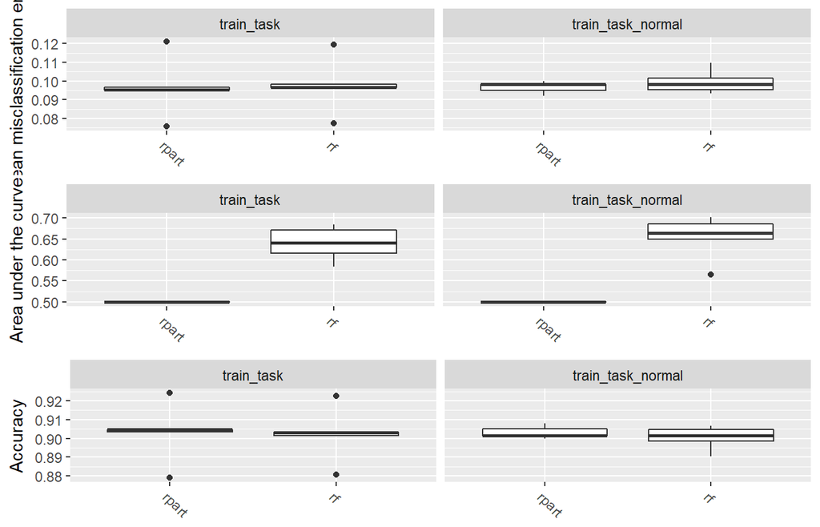

Fig. 1

```r
p1<-plotBMRBoxplots(bmr, measure = mmce)
p2<-plotBMRBoxplots(bmr, measure = auc)
p3<-plotBMRBoxplots(bmr, measure = acc)

layout <- matrix(c(1,2,3),3,1,byrow=TRUE)
multiplot(p1, p2, p3, layout=layout)
```

```r
mod_bmr=getBMRModels(bmr)
pred_bmr=predict(mod_bmr$train_task_$randomForest[[1]],task=test_task)
df = generateThreshVsPerfData(pred_bmr, measures = list(fpr, tpr, mmce))

#AUC performance on testing normal data with gbm
performance(pred_bmr, auc)
```

```
##       auc
## 0.5532792
```

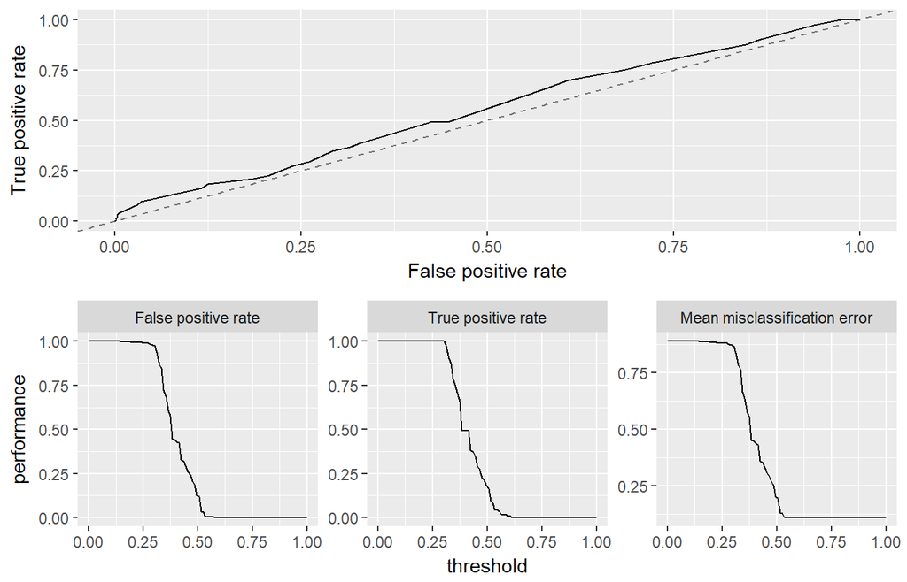

Fig. 1

```r
p1<-plotROCCurves(df)
p2<-plotThreshVsPerf(df)
layout <- matrix(c(1,2),2,1,byrow=TRUE)
multiplot(p1, p2, layout=layout)
```

## 5.3 GBM

```r
#load GBM
 getParamSet("classif.gbm")
```

```
##                       Type len   Def
## distribution      discrete   -     -
## n.trees            integer   -   100
## cv.folds           integer   -     0
## interaction.depth  integer   -     1
## n.minobsinnode     integer   -    10
## shrinkage          numeric   - 0.001
## bag.fraction       numeric   -   0.5
## train.fraction     numeric   -     1
## keep.data          logical   -  TRUE
## verbose            logical   - FALSE
##                                                     Constr Req Tunable
## distribution      bernoulli,adaboost,huberized,multinomial   -    TRUE
## n.trees                                           1 to Inf   -    TRUE
## cv.folds                                       -Inf to Inf   -    TRUE
## interaction.depth                                 1 to Inf   -    TRUE
## n.minobsinnode                                    1 to Inf   -    TRUE
## shrinkage                                         0 to Inf   -    TRUE
## bag.fraction                                        0 to 1   -    TRUE
## train.fraction                                      0 to 1   -    TRUE
## keep.data                                                -   -   FALSE
## verbose                                                  -   -   FALSE
##                   Trafo
## distribution          -
## n.trees               -
## cv.folds              -
## interaction.depth     -
## n.minobsinnode        -
## shrinkage             -
## bag.fraction          -
## train.fraction        -
## keep.data             -
## verbose               -
```

```r
 g.gbm <- makeLearner("classif.gbm", predict.type = "prob")

#specify tuning method
 rancontrol <- makeTuneControlRandom(maxit = 50L)

#3 fold cross validation
 set_cv <- makeResampleDesc("CV",iters = 3L)

#parameters
gbm_par<- makeParamSet(
makeDiscreteParam("distribution", values = "bernoulli"),
makeIntegerParam("n.trees", lower = 100, upper = 200), #number of trees
makeIntegerParam("interaction.depth", lower = 2, upper = 10), #depth of tree
makeIntegerParam("n.minobsinnode", lower = 10, upper = 50)
)
#tune parameters
meas = list(mmce, auc, acc,timetrain)
tune_gbm <- tuneParams(learner = g.gbm, task = train_task_normal,resampling = set_cv,measures = meas,par.set = gbm_par,control = rancontrol)
```

```
## [Tune] Started tuning learner classif.gbm for parameter set:
```

```
##                       Type len Def     Constr Req Tunable Trafo
## distribution      discrete   -   -  bernoulli   -    TRUE     -
## n.trees            integer   -   - 100 to 200   -    TRUE     -
## interaction.depth  integer   -   -    2 to 10   -    TRUE     -
## n.minobsinnode     integer   -   -   10 to 50   -    TRUE     -
```

```
## With control class: TuneControlRandom
```

```
## Imputation value: 1Imputation value: -0Imputation value: -0Imputation value: Inf
```

```
## Exporting objects to slaves for mode socket: .mlr.slave.options
```

```
## Mapping in parallel: mode = socket; cpus = 4; elements = 50.
```

```
## [Tune] Result: distribution=bernoulli; n.trees=121; interaction.depth=8; n.minobsinnode=22 : mmce.test.mean=0.0967393,auc.test.mean=0.6988294,acc.test.mean=0.9032607,timetrain.test.mean=1.5100000
```

```r
#check CV accuracy
tune_gbm$y
```

```
##      mmce.test.mean       auc.test.mean       acc.test.mean
##          0.09673926          0.69882945          0.90326074
## timetrain.test.mean
##          1.51000000
```

```r
#set parameters
final_gbm <- setHyperPars(learner = g.gbm, par.vals = tune_gbm$x)

#train
to.gbm <- mlr::train(final_gbm, train_task_normal)

#test
pr.gbm <- predict(to.gbm, test_task_normal)
#tesr performance
df = generateThreshVsPerfData(pr.gbm,measures = list(fpr, tpr, mmce))

#AUC performance on testing normal data with gbm
performance(pr.gbm, list(auc,acc))
```

```
##       auc       acc
## 0.6643459 0.8900602
```

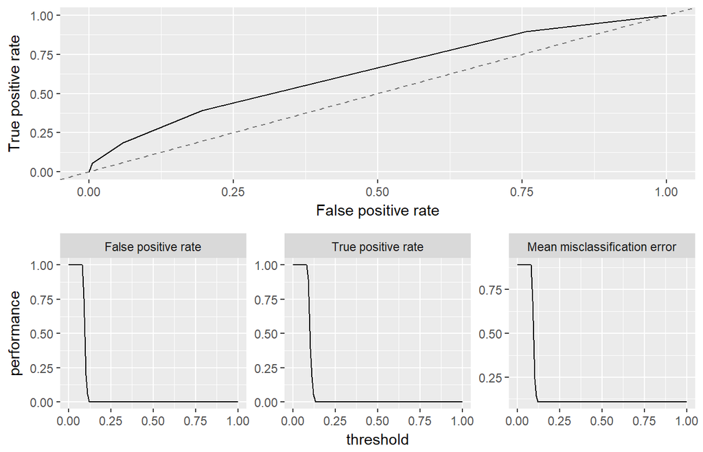

```r
p1<-plotROCCurves(df)
p2<-plotThreshVsPerf(df)
layout <- matrix(c(1,2),2,1,byrow=TRUE)
multiplot(p1, p2, layout=layout)
```

We want to compare different method of feature selection and get the idea of feature importance. Then we select limited number of features to train new model and compare the performance.

```r
#selecting top 30 important features based on random forest importance
fv = generateFilterValuesData(train_task, method = "rf.importance", abs = 20)
```

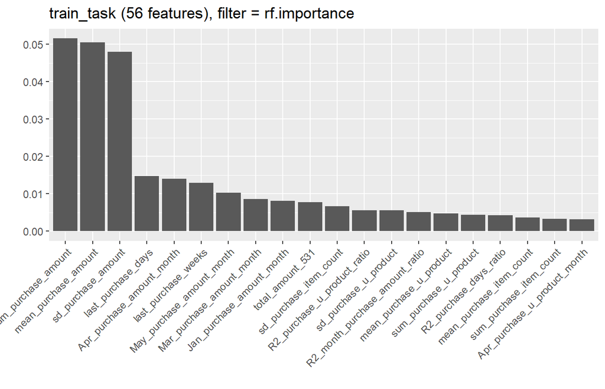

```r
plotFilterValues(fv)
```

```r
#Top 5:sum_purchase_amount,mean_purchase_amount,sd_purchase_amount,April_purchase_amount_month,last_purchase_days


# Compare with the feature importance based on gbm model
FI_gbm<-getFeatureImportance(to.gbm)
#Top 5:total_amount_531,sum_purchase_amount,last_purchase_days,sd_purchase_amount,May_purchase_amount_month
```

Training gbm model with top 20 features. The performance(AUC:0.69,ACC:0.90) on training dataset is the same with gbm with all features. The performance on testing data is almost the same(AUC:0.66,ACC:0.89).Considering overfitting, we decide to choose the model with 20 features.

```r
top_task <- filterFeatures(train_task_normal, method = "rf.importance", abs = 20)
set.seed(1234)

tune_gbm_top <- tuneParams(learner = g.gbm, task = top_task,resampling = set_cv,measures = meas,par.set = gbm_par,control = rancontrol)
```

```
## [Tune] Started tuning learner classif.gbm for parameter set:
```

```
##                       Type len Def     Constr Req Tunable Trafo
## distribution      discrete   -   -  bernoulli   -    TRUE     -
## n.trees            integer   -   - 100 to 200   -    TRUE     -
## interaction.depth  integer   -   -    2 to 10   -    TRUE     -
## n.minobsinnode     integer   -   -   10 to 50   -    TRUE     -
```

```
## With control class: TuneControlRandom
```

```
## Imputation value: 1Imputation value: -0Imputation value: -0Imputation value: Inf
```

```
## Exporting objects to slaves for mode socket: .mlr.slave.options
```

```
## Mapping in parallel: mode = socket; cpus = 4; elements = 50.
```

```
## [Tune] Result: distribution=bernoulli; n.trees=126; interaction.depth=7; n.minobsinnode=38 : mmce.test.mean=0.0967446,auc.test.mean=0.6985346,acc.test.mean=0.9032554,timetrain.test.mean=0.6300000
```

```r
#check CV performance
tune_gbm_top$y
```

```
##      mmce.test.mean       auc.test.mean       acc.test.mean
##          0.09674457          0.69853461          0.90325543
## timetrain.test.mean
##          0.63000000
```

```r
#set parameters
final_gbm_top <- setHyperPars(learner = g.gbm, par.vals = tune_gbm_top$x)

#train
to.gbm_top <- mlr::train(final_gbm_top, top_task)

#test
gbm_top_task = subsetTask(test_task_normal, features = to.gbm_top$features)
pr.gbm.top <- predict(to.gbm_top, gbm_top_task)
#test performance
df.top = generateThreshVsPerfData(pr.gbm.top,measures = list(fpr, tpr, mmce))

#AUC performance on testing normal data with gbm
performance(pr.gbm.top, list(mmce,auc,acc))
```

```
##      mmce       auc       acc
## 0.1099398 0.6619324 0.8900602
```

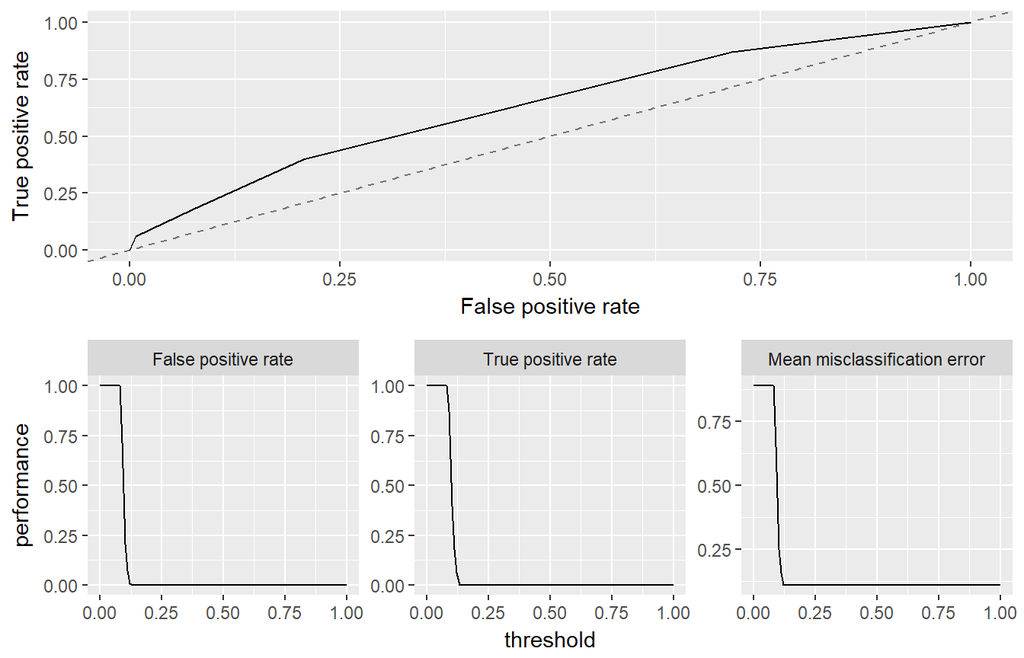

```r
p1<-plotROCCurves(df.top)
p2<-plotThreshVsPerf(df.top)
layout <- matrix(c(1,2),2,1,byrow=TRUE)
multiplot(p1, p2, layout=layout)
```

## 5.4 Model decision

```r
#Model description
to.gbm_top$learner.model
```

```
## gbm::gbm(formula = f, distribution = "bernoulli", data = d, n.trees = 126L,
##     interaction.depth = 7L, n.minobsinnode = 38L, keep.data = FALSE)
## A gradient boosted model with bernoulli loss function.
## 126 iterations were performed.
## There were 20 predictors of which 17 had non-zero influence.
```

```r
#Feature selected
to.gbm_top$features
```

```
##  [1] "Jan_purchase_amount_month"      "Mar_purchase_amount_month"
##  [3] "Apr_purchase_amount_month"      "May_purchase_amount_month"
##  [5] "sum_purchase_amount"            "sum_purchase_u_product"
##  [7] "mean_purchase_item_count"       "mean_purchase_amount"
##  [9] "mean_purchase_u_product"        "sd_purchase_item_count"
## [11] "sd_purchase_amount"             "sd_purchase_u_product"
## [13] "R1_month_purchase_amount_ratio" "R2_month_purchase_amount_ratio"
## [15] "R2_purchase_u_product_ratio"    "R2_purchase_days_ratio"
## [17] "total_amount_531"               "last_purchase_days"
## [19] "last_purchase_weeks"            "sales_method.unknown"
```

```r
#Feature importance
getFeatureImportance(to.gbm_top)
```

```
## FeatureImportance:
## Task: train_task_normal
##
## Learner: classif.gbm
## Measure: NA
## Contrast: NA
## Aggregation: function (x)  x
## Replace: NA
## Number of Monte-Carlo iterations: NA
## Local: FALSE
##   Jan_purchase_amount_month Mar_purchase_amount_month
## 1                  5.391361                  4.120616
##   Apr_purchase_amount_month May_purchase_amount_month sum_purchase_amount
## 1                  25.95109                   66.9155            242.0715
##   sum_purchase_u_product mean_purchase_item_count mean_purchase_amount
## 1               11.97864                 9.746752                    0
##   mean_purchase_u_product sd_purchase_item_count sd_purchase_amount
## 1                       0               41.12818           124.3353
##   sd_purchase_u_product R1_month_purchase_amount_ratio
## 1              28.24833                        4.95772
##   R2_month_purchase_amount_ratio R2_purchase_u_product_ratio
## 1                       4.210442                    9.391579
##   R2_purchase_days_ratio total_amount_531 last_purchase_days
## 1                      0         625.1242           111.5916
##   last_purchase_weeks sales_method.unknown
## 1            23.76028             10.45159
```

```r
#Performance on training and testing data

#performance on training
tune_gbm_top$y
```

```
##      mmce.test.mean       auc.test.mean       acc.test.mean
##          0.09674457          0.69853461          0.90325543
## timetrain.test.mean
##          0.63000000
```

```r
#performance on testing
performance(pr.gbm.top, list(mmce,auc,acc))
```

```
##      mmce       auc       acc
## 0.1099398 0.6619324 0.8900602
```

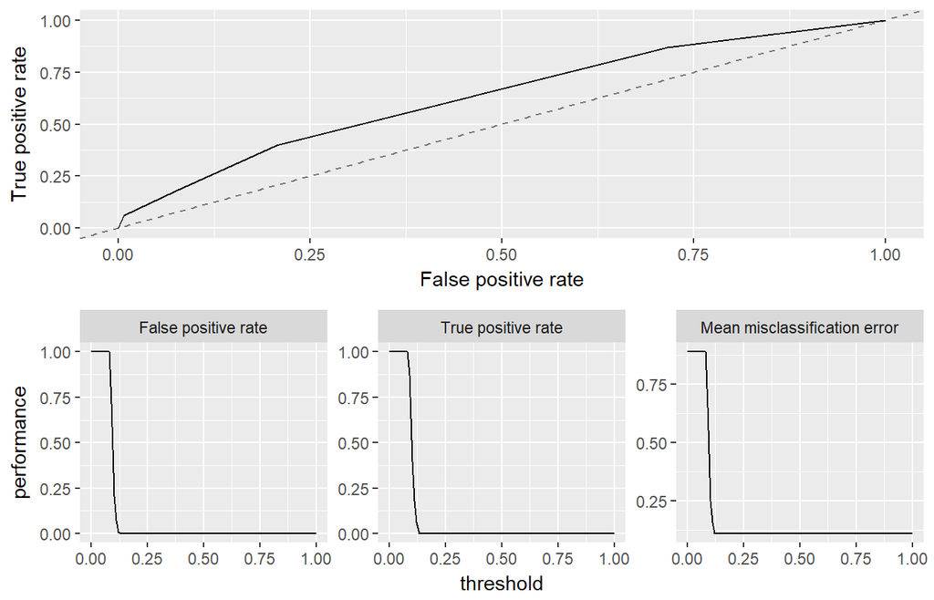

```r
#Plot
multiplot(p1, p2, layout=layout)
```

# 6 Go back to feature importance

Let’s plot the top important feature relationship with *flag* Top 5:total_amount_531,sum_purchase_amount,last_purchase_days,sd_purchase_amount,May_purchase_amount_month

## 6.1 Interaction-Numeric features with target

Here we have some very important and interesting findings.

1. total_amount_531: It’s the accumlated purchase amount to 2016.05.31(not starts from 2016). Customer with higher accumlated purchase amount has the higher chance to purchase again in next 2 months.
2. sum_purchase_amount: It’s the total purchase amount between 2016.01.01-2016.05.31. There are two trends.Customer with highest and lowest total purchase amount in 2016 has the higher chance to purchase again in next 2 months.
3. last_purchase_days: It’s the day between customer last purchase date and 2016.05.31. We could see there’re two very strong indicators. Customers who haven’t purchase for 48 days (7 weeks) or 83 days (12 weeks) are most likely to purchase in the next 2 months.
4. sd_purchase_amount:It’s the standard deviation of total purchase amount in each month of 2016 for each customer. Customers whose purchase amount with lower variance have higher repeated purchase chance.
5. May_purchase_amount_month: It’s the total purchase amount in May. We could see clear that customers with lowest purchase amount in May have higher chance to purchase in next 2 months.

To summary, the importance features of repeated purchase are all about time and purchase amount. Customers who bought a lot and who didn’t buy anything in 7/12 weeks have the high probability to buy in the next two months!

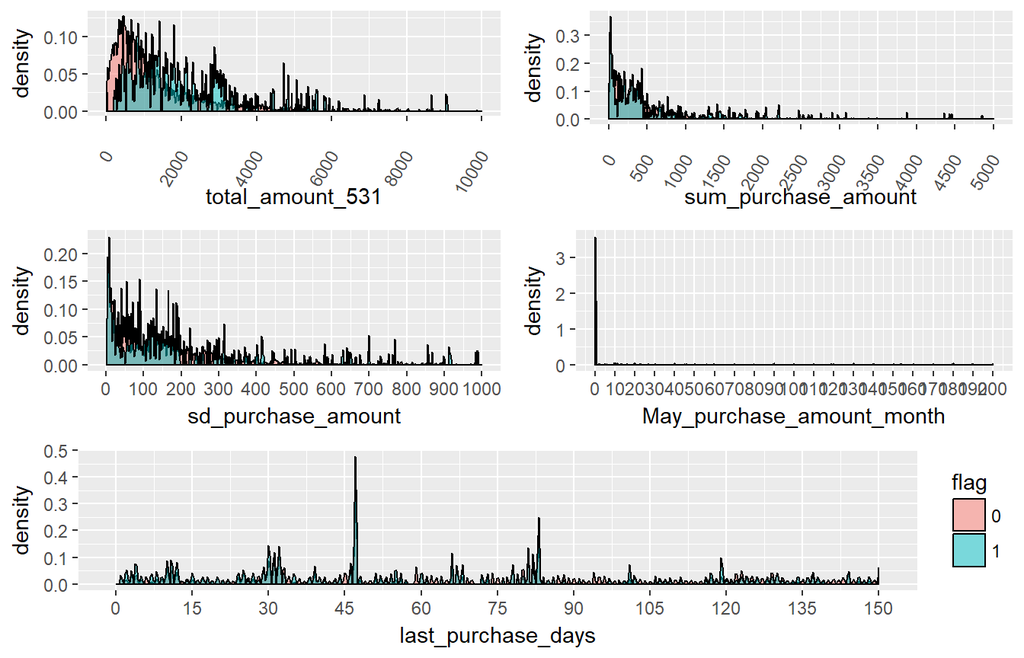

Fig. 4

```r
p1 <- df_train%>%
  ggplot(aes(total_amount_531, fill =flag)) +
  geom_density(alpha = 0.5, bw = 0.05) +
  theme(legend.position = "none",axis.text.x=element_text(angle=60,hjust=1,vjust=0.5))+
  scale_x_continuous(limits=c(1,10000),breaks=seq(0,10000,2000))


p2 <- df_train %>%
  ggplot(aes(sum_purchase_amount, fill =flag)) +
  geom_density(alpha = 0.5, bw = 0.05)+
  theme(legend.position = "none",axis.text.x=element_text(angle=60,hjust=1,vjust=0.5))+
  scale_x_continuous(limits=c(1,5000),breaks=seq(0,5000,500))

p3 <- df_train %>%
  ggplot(aes(last_purchase_days, fill =flag)) +
  geom_density(alpha = 0.5, bw = 0.05)+
  scale_x_continuous(limits=c(0,150),breaks=seq(0,150,15))

p4 <- df_train %>%
  ggplot(aes(sd_purchase_amount, fill =flag)) +
  geom_density(alpha = 0.5, bw = 0.05)+
  theme(legend.position = "none")+
  scale_x_continuous(limits=c(1,1000),breaks=seq(0,1000,100))

p5 <- df_train %>%
  ggplot(aes(May_purchase_amount_month, fill =flag)) +
  geom_density(alpha = 0.5, bw = 0.05)+
  theme(legend.position = "none")+
  scale_x_continuous(limits=c(0,200),breaks=seq(0,200,10))


layout <- matrix(c(1,2,3,4,5,5),3,2,byrow=TRUE)
 multiplot(p1, p2,p4,p5,p3, layout=layout)
```